# Final Project: Network Intrusion Detection

The Marauders: Karan Shah(kshah1), Kunal Kumar Gupta(kunalkug), Tweesha Joshi(tweeshaj)

```r
library(tidyverse)
library(dplyr)
library(ggplot2)
library(knitr)
library(stringr)
library(caret)
library(FactoMineR)
library(glmnet)
library(plyr)
library(scales)
library(klaR)
library(randomForest)
library(pROC)
library(magrittr)
library(cluster)
library(Rtsne)
library(anomalyDetection)
library(distances)
library(lme4)
library(MVN)
library(factoextra)
library(dendextend)

set.seed(1)

options(scipen = 4)

#Importing system log data for network traffic analysis
network.traffic <- read.table("http://www.andrew.cmu.edu/user/achoulde/95791/projects/Project%20E/network_traffic.csv", header = TRUE, sep = ",")
```

## *Introduction*

*XYZ Bank is a large and profitable bank in Saint Louis, Missouri. Like any large corporation, XYZ Bank has a very large and intricate infrastructure that supports its networking system. A Network Analyst recently discovered unusual network activity. Then, pouring over year’s worth of logs, their team of analysts discovered many instances of anomalous network activity that resulted in significant sums of money being siphoned from bank accounts. The Chief Networking Officer has come to us for help in developing a system that can automatically detect and warn of such known, as well as other unknown, anomalous network activities.*

## *Key tasks completed*

*1. Determined that it is possible to differentiate between the labeled intrusions and benign sessions.*

*2. It is possible to identify different types of intrusions. We were successful in getting the attributes that contribute to the types of network intrusions in the data.*

*3. Developed and implemented a systematic approach to detect instances of intrusions in log files. Our system can take a new network_traffic log file and determine the existence of known patterns of intrusions as well as anomalies which may be indicative of new and unknown intrusion patterns.*

*4. Evaluated the detection power of our system.*

*5. Our intrusion detector can be used in real-time. It can receive data about a current session, and in seconds determine if it is likely to be an intrusion of previously seen type or an anomaly potentially signifying an unseen yet intrusion mode. We also give recommendations about what information should be exchanged via the user interface of the system.*

## *Data Cleaning*

*In order to get started on classification and picking the best model for prediction, some of our data needed to be handeled. For example, there were some incidences in the data that needed to be removed such as a “=0” value in attribute is_intrusion. This level was dropped from the variable is_intrusion which now contains two factors, 0 and 1. Also, in another binary factor variable su_attempted, there was a max value of 2 which changed to 1.Below, you can see the summary of the data and where these issues were seen.*

```r
str(network.traffic)
```

```
## 'data.frame':    3000 obs. of  23 variables:
##  $ duration          : int  0 0 0 0 0 0 0 0 0 0 ...
##  $ protocol_type     : Factor w/ 3 levels "icmp","tcp","udp": 2 2 2 2 2 2 2 2 2 2 ...
##  $ service           : Factor w/ 16 levels "auth","domain_u",..: 8 8 8 8 8 8 8 8 8 8 ...
##  $ flag              : Factor w/ 6 levels "REJ","RSTO","RSTR",..: 6 6 6 6 6 6 6 6 6 6 ...
##  $ src_bytes         : int  302 339 260 213 308 230 221 329 271 326 ...
##  $ dst_bytes         : int  896 1588 7334 8679 1658 505 445 2431 688 566 ...
##  $ land              : int  0 0 0 0 0 0 0 0 0 0 ...
##  $ wrong_fragment    : int  0 0 0 0 0 0 0 0 0 0 ...
##  $ urgent            : int  0 0 0 0 0 0 0 0 0 0 ...
##  $ hot               : int  0 0 0 0 0 0 0 0 0 0 ...
##  $ num_failed_logins : int  0 0 0 0 0 0 0 0 0 0 ...
##  $ logged_in         : int  1 1 1 1 1 1 1 1 1 1 ...
##  $ num_compromised   : int  0 0 0 0 0 0 0 0 0 0 ...
##  $ root_shell        : int  0 0 0 0 0 0 0 0 0 0 ...
##  $ su_attempted      : int  0 0 0 0 0 0 0 0 0 0 ...
##  $ num_root          : int  0 0 0 0 0 0 0 0 0 0 ...
##  $ num_file_creations: int  0 0 0 0 0 0 0 0 0 0 ...
##  $ num_shells        : int  0 0 0 0 0 0 0 0 0 0 ...
##  $ num_access_files  : int  0 0 0 0 0 0 0 0 0 0 ...
##  $ num_outbound_cmds : int  0 0 0 0 0 0 0 0 0 0 ...
##  $ is_host_login     : int  0 0 0 0 0 0 0 0 0 0 ...
##  $ is_guest_login    : int  0 0 0 0 0 0 0 0 0 0 ...
##  $ is_intrusion      : Factor w/ 3 levels "0","0=","1": 1 1 1 1 1 1 1 1 1 1 ...
```

```r
#Removed =0 from data
network.traffic$dst_bytes[network.traffic$dst_bytes == "5005"] <- NA
network.traffic <- network.traffic[complete.cases(network.traffic),]
network.traffic$is_intrusion <- droplevels(network.traffic$is_intrusion)
str(network.traffic)
```

```
## 'data.frame':    2999 obs. of  23 variables:
##  $ duration          : int  0 0 0 0 0 0 0 0 0 0 ...
##  $ protocol_type     : Factor w/ 3 levels "icmp","tcp","udp": 2 2 2 2 2 2 2 2 2 2 ...
##  $ service           : Factor w/ 16 levels "auth","domain_u",..: 8 8 8 8 8 8 8 8 8 8 ...
##  $ flag              : Factor w/ 6 levels "REJ","RSTO","RSTR",..: 6 6 6 6 6 6 6 6 6 6 ...
##  $ src_bytes         : int  302 339 260 213 308 230 221 329 271 326 ...
##  $ dst_bytes         : int  896 1588 7334 8679 1658 505 445 2431 688 566 ...
##  $ land              : int  0 0 0 0 0 0 0 0 0 0 ...
##  $ wrong_fragment    : int  0 0 0 0 0 0 0 0 0 0 ...
##  $ urgent            : int  0 0 0 0 0 0 0 0 0 0 ...
##  $ hot               : int  0 0 0 0 0 0 0 0 0 0 ...
##  $ num_failed_logins : int  0 0 0 0 0 0 0 0 0 0 ...
##  $ logged_in         : int  1 1 1 1 1 1 1 1 1 1 ...
##  $ num_compromised   : int  0 0 0 0 0 0 0 0 0 0 ...
##  $ root_shell        : int  0 0 0 0 0 0 0 0 0 0 ...
##  $ su_attempted      : int  0 0 0 0 0 0 0 0 0 0 ...
##  $ num_root          : int  0 0 0 0 0 0 0 0 0 0 ...
##  $ num_file_creations: int  0 0 0 0 0 0 0 0 0 0 ...
##  $ num_shells        : int  0 0 0 0 0 0 0 0 0 0 ...
##  $ num_access_files  : int  0 0 0 0 0 0 0 0 0 0 ...
##  $ num_outbound_cmds : int  0 0 0 0 0 0 0 0 0 0 ...
##  $ is_host_login     : int  0 0 0 0 0 0 0 0 0 0 ...
##  $ is_guest_login    : int  0 0 0 0 0 0 0 0 0 0 ...
##  $ is_intrusion      : Factor w/ 2 levels "0","1": 1 1 1 1 1 1 1 1 1 1 ...
```

```r
#Use summary table
summary(network.traffic)
```

```
##     duration       protocol_type     service       flag
##  Min.   :    0.0   icmp:  40     http    :1911   REJ : 154
##  1st Qu.:    0.0   tcp :2449     smtp    : 290   RSTO:   1
##  Median :    0.0   udp : 510     private : 247   RSTR:  65
##  Mean   :  118.1                 domain_u: 185   S0  :  33
##  3rd Qu.:    0.0                 ftp_data: 169   S3  :   2
##  Max.   :24204.0                 other   :  58   SF  :2744
##                                  (Other) : 139
##    src_bytes          dst_bytes           land   wrong_fragment
##  Min.   :     0.0   Min.   :     0   Min.   :0   Min.   :0
##  1st Qu.:   132.5   1st Qu.:   118   1st Qu.:0   1st Qu.:0
##  Median :   228.0   Median :   388   Median :0   Median :0
##  Mean   :  4569.2   Mean   :  2705   Mean   :0   Mean   :0
##  3rd Qu.:   316.0   3rd Qu.:  1952   3rd Qu.:0   3rd Qu.:0
##  Max.   :283618.0   Max.   :273544   Max.   :0   Max.   :0
##
##      urgent       hot           num_failed_logins   logged_in
##  Min.   :0   Min.   : 0.00000   Min.   :0         Min.   :0.0000
##  1st Qu.:0   1st Qu.: 0.00000   1st Qu.:0         1st Qu.:0.0000
##  Median :0   Median : 0.00000   Median :0         Median :1.0000
##  Mean   :0   Mean   : 0.06602   Mean   :0         Mean   :0.7176
##  3rd Qu.:0   3rd Qu.: 0.00000   3rd Qu.:0         3rd Qu.:1.0000
##  Max.   :0   Max.   :25.00000   Max.   :0         Max.   :1.0000
##
##  num_compromised      root_shell     su_attempted          num_root
##  Min.   :  0.0000   Min.   :0.000   Min.   :0.0000000   Min.   :  0.0000
##  1st Qu.:  0.0000   1st Qu.:0.000   1st Qu.:0.0000000   1st Qu.:  0.0000
##  Median :  0.0000   Median :0.000   Median :0.0000000   Median :  0.0000
##  Mean   :  0.2968   Mean   :0.001   Mean   :0.0006669   Mean   :  0.3478
##  3rd Qu.:  0.0000   3rd Qu.:0.000   3rd Qu.:0.0000000   3rd Qu.:  0.0000
##  Max.   :884.0000   Max.   :1.000   Max.   :2.0000000   Max.   :975.0000
##
##  num_file_creations   num_shells        num_access_files
##  Min.   :0.000      Min.   :0.0000000   Min.   :0.000000
##  1st Qu.:0.000      1st Qu.:0.0000000   1st Qu.:0.000000
##  Median :0.000      Median :0.0000000   Median :0.000000
##  Mean   :0.001      Mean   :0.0003334   Mean   :0.004668
##  3rd Qu.:0.000      3rd Qu.:0.0000000   3rd Qu.:0.000000
##  Max.   :1.000      Max.   :1.0000000   Max.   :5.000000
##
##  num_outbound_cmds is_host_login is_guest_login  is_intrusion
##  Min.   :0         Min.   :0     Min.   :0.000   0:2699
##  1st Qu.:0         1st Qu.:0     1st Qu.:0.000   1: 300
##  Median :0         Median :0     Median :0.000
##  Mean   :0         Mean   :0     Mean   :0.015
##  3rd Qu.:0         3rd Qu.:0     3rd Qu.:0.000
##  Max.   :0         Max.   :0     Max.   :1.000
##
```

```r
#Cite: https://tgmstat.wordpress.com/2014/03/06/near-zero-variance-predictors/
variance <- nearZeroVar(network.traffic, saveMetrics = TRUE)

#Remove variables with no variance
network.traffic <- network.traffic[variance$zeroVar == FALSE]


#Max Error in discreet variable su_attempted
network.traffic[which(network.traffic$su_attempted == 2),11] <- 1
```

## *Exploratory Data Analysis*

**Getting to know the data**

```r
head(network.traffic,10)
```

```
##    duration protocol_type service flag src_bytes dst_bytes hot logged_in
## 1         0           tcp    http   SF       302       896   0         1
## 2         0           tcp    http   SF       339      1588   0         1
## 3         0           tcp    http   SF       260      7334   0         1
## 4         0           tcp    http   SF       213      8679   0         1
## 5         0           tcp    http   SF       308      1658   0         1
## 6         0           tcp    http   SF       230       505   0         1
## 7         0           tcp    http   SF       221       445   0         1
## 8         0           tcp    http   SF       329      2431   0         1
## 9         0           tcp    http   SF       271       688   0         1
## 10        0           tcp    http   SF       326       566   0         1
##    num_compromised root_shell su_attempted num_root num_file_creations
## 1                0          0            0        0                  0
## 2                0          0            0        0                  0
## 3                0          0            0        0                  0
```

[output cut: 18 more lines]

*After conducting some preliminary analysis and data cleaning, we realized that were were many variables that had a variance of zero and wouldn’t be helpful in our analysis. These 6 variables were removed from the data. We now have 2999 observations of data on 17 attributes related to network intrusions for XYZ Bank. Moving forward, all models and analysis will be run on this data set.*

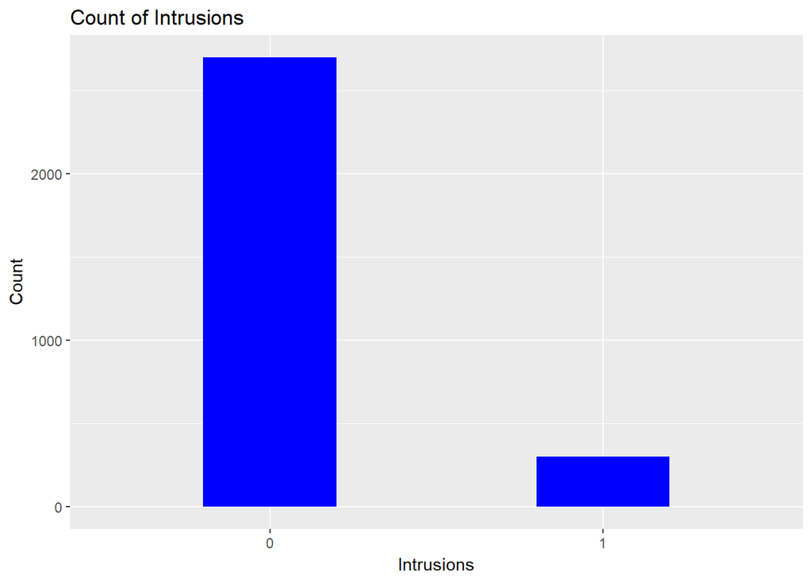

```r
#Graph of Intrusions
intrusion.plot <- ggplot(data = network.traffic, mapping = aes(x = is_intrusion)) + geom_histogram(stat = "count", fill = "blue", width = 0.4) + xlab("Intrusions") + ylab("Count") + ggtitle("Count of Intrusions")
intrusion.plot
```

```r
table(network.traffic$is_intrusion)
```

```
##
##    0    1
## 2699  300
```

*The histogram shows us a count of the intrusions seen in our data. As a categorical variable, 1 represents an intrusion and 0 represents a benign session. There are 300 intrusions recorded in our data out of 2999 observations.*

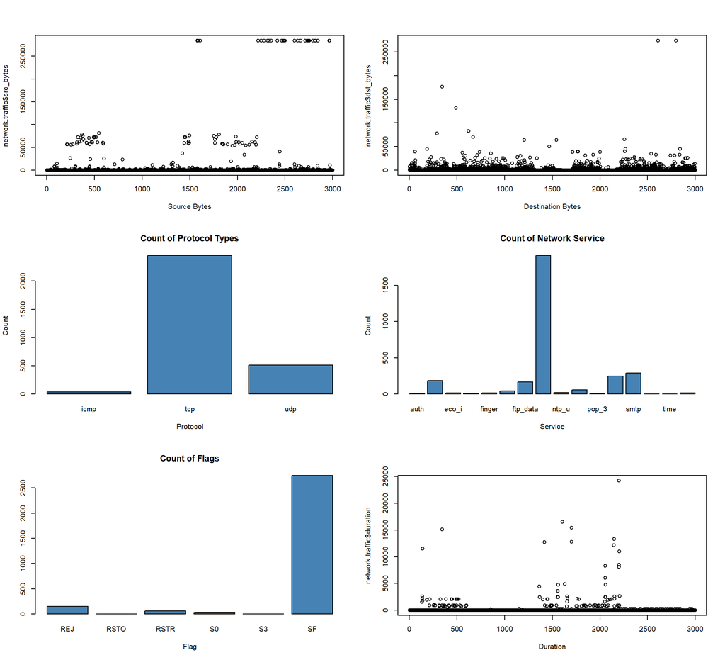

```r
par(mfrow = c(3,2))
plot(network.traffic$src_bytes, xlab= "Source Bytes")
plot(network.traffic$dst_bytes, xlab = "Destination Bytes")
plot(network.traffic$protocol_type, main = "Count of Protocol Types", xlab = "Protocol", ylab = "Count", col = "steelblue")
plot(network.traffic$service, main= "Count of Network Service", xlab = "Service", ylab = "Count", col = "steelblue")
plot(network.traffic$flag, main = "Count of Flags", xlab= "Flag", col= "steelblue")
plot(network.traffic$duration, xlab = "Duration")
```

*These graphs summarize some important variables from our data. As shown, the number of data bytes from source to destination are much larger than the number of data bytes from destination to source. There are many outliers in source bytes that are above 250,000 bytes that could signify a relationship to intrusions. Furthermore, the most amount of data points are made up of protocol type “tcp”, network service type “http”, and flag as “SF” which is a normal status of connection. The last plot at the bottom right shows duration in terms of lenght (number of seconds) of connection. Here we see some data points of duration that are larger than usual.*

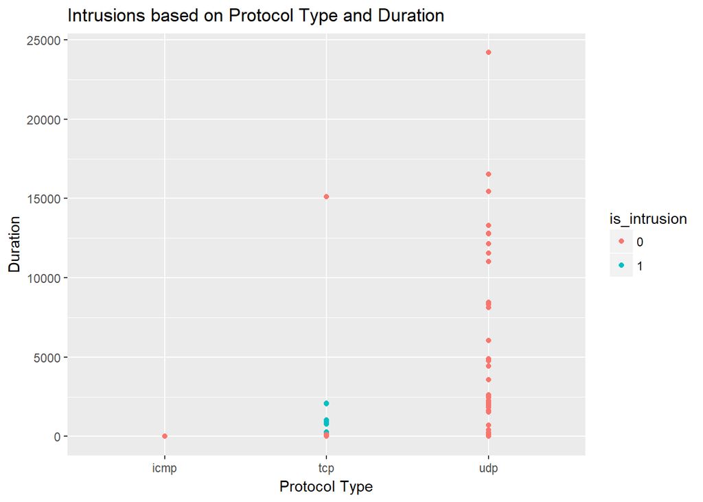

```r
qplot(x=protocol_type, y=duration, data=network.traffic,
      color = is_intrusion,
      xlab = "Protocol Type",
      ylab = "Duration",
      main = "Intrusions based on Protocol Type and Duration")
```

*This graph shows that the most amount of intrusions were of protocol type “tcp” while the longest duration of connections were of type “udp”. This helps us to see which protocol types were most prone to intrusions, tcp.*

```r
kable(with(network.traffic, round(tapply(duration, INDEX = list(is_intrusion, protocol_type), FUN = mean),2)), format = "markdown")
```

|  | icmp | tcp | udp |
| --- | --- | --- | --- |
| 0 | 0 | 8.00 | 594.12 |
| 1 | NA | 463.21 | 0.02 |

*The average length of duration for intrusions of type “tcp” was 463.21 seconds.*

```r
kable(with(network.traffic, round(tapply(duration, INDEX = list(is_intrusion, service), FUN = mean),2)), format = "markdown")
```

|  | auth | domain_u | eco_i | ecr_i | finger | ftp | ftp_data | http | ntp_u | other | pop_3 | private | smtp | telnet | time | urp_i |
| --- | --- | --- | --- | --- | --- | --- | --- | --- | --- | --- | --- | --- | --- | --- | --- | --- |
| 0 | 4.12 | 0.62 | 0 | 0 | 13.5 | 25.92 | 0.00 | 0.41 | 0 | 4196.09 | 3.83 | 0.69 | 2.37 | 5340.33 | 1 | 0 |
| 1 | NA | NA | NA | NA | NA | 282.06 | 125.37 | 749.35 | NA | NA | NA | 0.02 | NA | NA | NA | NA |

*This table shows an average of duration lenght broken down by service and intrusions. The most common network service on the destination for intrusions was “http”. The average length of duration for intrusions of network service “http” was 749.35 seconds.*

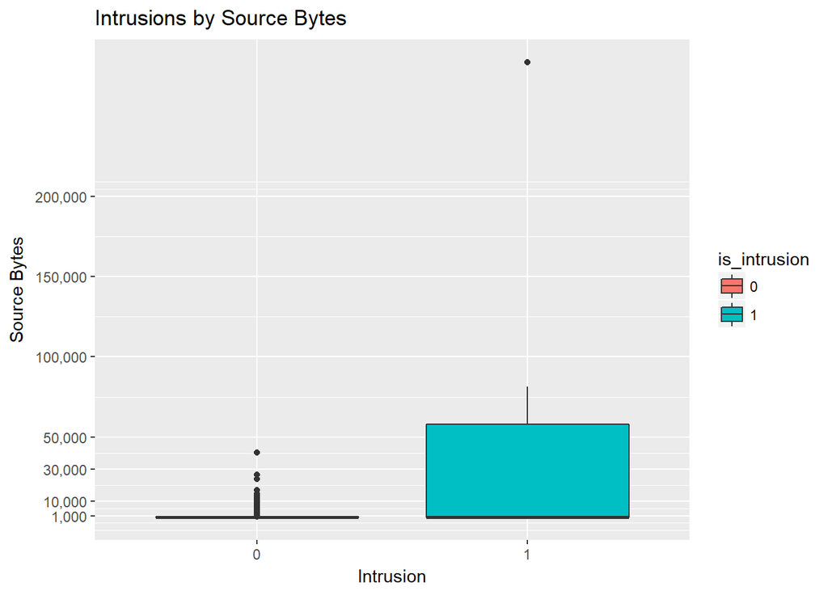

```r
ggplot(data = network.traffic, mapping = aes(x=is_intrusion, y=src_bytes, fill = is_intrusion)) +
  geom_boxplot() +
  xlab ("Intrusion") +
  ylab ("Source Bytes") +
  ggtitle("Intrusions by Source Bytes") +
  scale_y_continuous(labels = comma, breaks = c(1000, 10000, 30000, 50000, 100000, 150000, 200000))
```

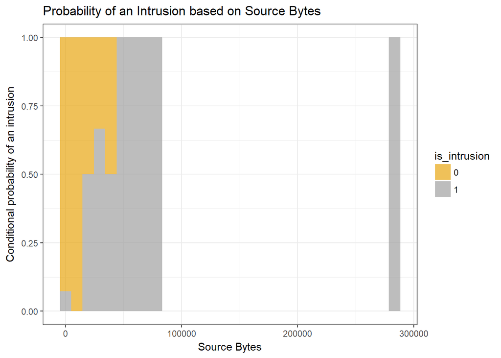

```r
cbPalette <- c("#999999", "#E69F00", "#56B4E9", "#009E73", "#F0E442", "#0072B2", "#D55E00", "#CC79A7")


qplot(data = network.traffic, x = src_bytes,
       ylab = "Conditional probability of an intrusion", geom = "blank") + ylim(0,1) +
  geom_histogram(data = network.traffic,
                 position = "fill", alpha = I(0.65),
                 aes(x = src_bytes, fill = is_intrusion),
                 show.legend = TRUE) +
  scale_fill_manual(values=cbPalette[c(2,1)]) + theme_bw() + xlab("Source Bytes") + ggtitle("Probability of an Intrusion based on Source Bytes")
```

*Both these graphs, the boxplot and conditional probability plot, reconfirm what we found from our plots above that source bytes that are larger are classified as intrusions. Even the extremely larger number of source bytes that are outliers in our data are marked as intrusions.*

### Transforming duration column for Rates

```r
network.transformed <- network.traffic

duration.transformed <- network.transformed %>% dplyr::select(duration) %>% mutate(duration.transformed = duration + 1) %>% dplyr::select(-duration)


network.transformed <- cbind(network.transformed, duration.transformed)
network.transformed <- dplyr::select(network.transformed, -duration)
network.transformed <- (network.transformed[c(17,1:16)])
```

```r
network.transformed <- network.transformed %>% mutate(source_rate = src_bytes/duration.transformed)
with(network.transformed,tapply(source_rate, INDEX = list(is_intrusion), FUN = mean))
```

```
##        0        1
## 419.9123 150.1128
```

```r
#Source Rate when there is an intrusion
```

*The average source rate during an intrusion is 150.1127868 bytes per second.*

```r
network.transformed <- network.transformed %>% mutate(dest_rate = dst_bytes/duration.transformed)
with(network.transformed,tapply(dest_rate, INDEX = list(is_intrusion), FUN = mean)) #Destination Rate when there is an intrusion
```

```
##          0          1
## 2805.33252   47.60435
```

*The average destination rate during an intrusion is 47.6043468 bytes per second.*

```r
network.transformed <- network.transformed %>% mutate(transmission_rate = source_rate + dest_rate)
network.transformed <- (network.transformed[c(1:6, 18:20, 7:17)])
with(network.transformed,tapply(transmission_rate, INDEX = list(is_intrusion), FUN = mean)) #Transmission Rate when there is an intrusion
```

```
##         0         1
## 3225.2448  197.7171
```

*The average total rate during an intrusion is 197.7171335 total bytes per second.*

```r
head(network.transformed, digits = c(3), caption = network.transformed, longtable = TRUE,10) #Table of Network Traffic data
```

```
##    duration.transformed protocol_type service flag src_bytes dst_bytes
## 1                     1           tcp    http   SF       302       896
## 2                     1           tcp    http   SF       339      1588
## 3                     1           tcp    http   SF       260      7334
## 4                     1           tcp    http   SF       213      8679
## 5                     1           tcp    http   SF       308      1658
## 6                     1           tcp    http   SF       230       505
## 7                     1           tcp    http   SF       221       445
## 8                     1           tcp    http   SF       329      2431
## 9                     1           tcp    http   SF       271       688
## 10                    1           tcp    http   SF       326       566
##    source_rate dest_rate transmission_rate hot logged_in num_compromised
## 1          302       896              1198   0         1               0
## 2          339      1588              1927   0         1               0
## 3          260      7334              7594   0         1               0
```

[output cut: 29 more lines]

*Here we created tramission rates for source bytes, destination bytes, and total bytes with both source and destination for intrusions. This tells us the rate, bytes per second, at which the incident took place.*

### Pairs Plot: All Variables

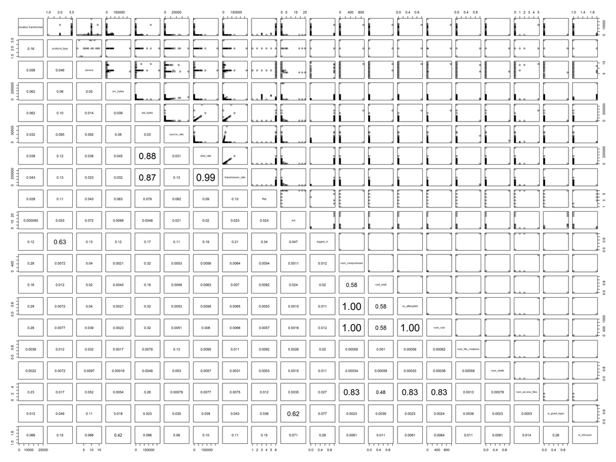

```r
panel.cor <- function(x, y, digits = 2, prefix = "", cex.cor, ...)
{
    usr <- par("usr"); on.exit(par(usr))
    par(usr = c(0, 1, 0, 1))
    require(polycor)
    r <- abs(cor(x, y))
    txt <- format(c(r, 0.123456789), digits = digits)[1]
    txt <- paste0(prefix, txt)
    if(missing(cex.cor)) cex.cor <- 0.8/strwidth(txt)
    text(0.5, 0.5, txt, cex = pmax(1, cex.cor * r))

}


pairs(network.transformed[c("duration.transformed",
                        "protocol_type",
                        "service",
                        "src_bytes",
                        "dst_bytes",
                        "source_rate",
                        "dest_rate",
                        "transmission_rate",
                        "flag",
                        "hot",
                        "logged_in",
                        "num_compromised",
                        "root_shell",
                        "su_attempted",
                        "num_root",
                        "num_file_creations",
                        "num_shells",
                        "num_access_files",
                        "is_guest_login",
                        "is_intrusion")], lower.panel = panel.cor)
```

### Pairs Plot: Highly Correlated Variables

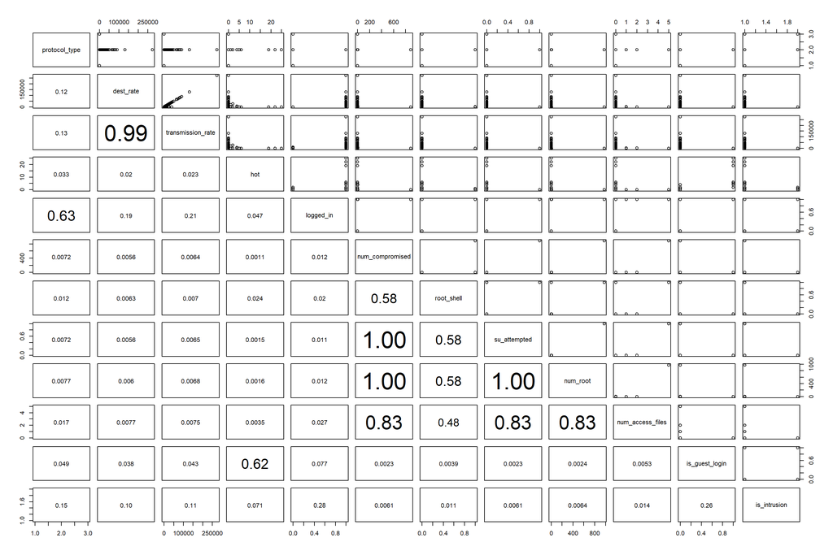

```r
#Reduced pair plot
pairs(network.transformed[c(#"duration.transformed",
                        "protocol_type",
                        #"service",
                        #"src_bytes",
                        #"dst_bytes",
                        #"source_rate",
                        "dest_rate",
                        "transmission_rate",
                        #"flag",
                        "hot",
                        "logged_in",
                        "num_compromised",
                        "root_shell",
                        "su_attempted",
                        "num_root",
                        #"num_file_creations",
                        #"num_shells",
                        "num_access_files",
                        "is_guest_login",
                        "is_intrusion")], lower.panel = panel.cor)
```

*From our pairs plot above, we see that some variables are highly correlated. Variables that were perfectly correlated with a correlation of 1, were removed from the data.*

```r
#Remove perfectly correlated variables
network.reduced <- dplyr::select(network.transformed, c(-dest_rate, -su_attempted, -num_root))
```

```r
# Randomly select 20% of the data to be held out for model validation
test.indexes <- sample(1:nrow(network.reduced), round(0.2 * nrow(network.reduced)))
train.indexes <- setdiff(1:nrow(network.reduced), test.indexes)

# Splitting network.reduced dataset into train and test data
network.train <- network.reduced[train.indexes, ]
network.test <- network.reduced[test.indexes, ]
```

## *Classification Models for Benign and Network Intrusion Sessions*

**Differentiating between the labeled intrusions and benign sessions**

*The three classification models we chose were random forest, logistic lasso, and naive bayes. We have decided to choose these classification techniques because of their versatility in classifying mixed data.*

```r
classMetrics <- function(score, y, cutoff,
                         type = c("all", "accuracy", "sensitivity",
                                  "specificity", "ppv", "npv", "precision",
                                  "recall")) {
  type <- match.arg(type, several.ok = TRUE)
  n <- length(y)

  # Form confusion matrix
  score.factor <- factor(as.numeric(score >= cutoff), levels = c("0", "1"))
  confusion.mat <- table(score.factor, as.factor(y), dnn = list("predicted", "observed"))
  # Calculate all metrics
  acc <- sum(diag(confusion.mat)) / n
  sens <- confusion.mat[2,2] / sum(confusion.mat[,2])
  spec <- confusion.mat[1,1] / sum(confusion.mat[,1])
  ppv <- confusion.mat[2,2] / sum(confusion.mat[2,])
  npv <- confusion.mat[1,1] / sum(confusion.mat[1,])
  prec <- ppv
  rec <- sens

  metric.names <- c("accuracy", "sensitivity", "specificity",
                    "ppv", "npv", "precision", "recall")
  metric.vals <- c(acc, sens, spec, ppv, npv, prec, rec)

  # Form into data frame
  full.df <- data.frame(value = metric.vals)
  rownames(full.df) <- metric.names

  # Return just the requested subset of metrics
  if(type[1] == "all") {
    list(conf.mat = confusion.mat, perf = full.df)
  } else {
    list(conf.mat = confusion.mat,
         perf = subset(full.df, subset = metric.names %in% type))
  }
}
```

### Random Forest

```r
#Random Forest on the train data
network.rf <- randomForest(is_intrusion ~ . , data = network.train)

#Prediction on Test Data
rf.test.prob <- predict(network.rf, newdata = network.test, type="prob")[,2]

#Creating Roc Curve variables for random forest
roc.rf <- roc(network.test$is_intrusion, rf.test.prob)

#Optimal Cutoff value balancing sensitivity and specificity
cutoff<- roc.rf$thresholds[which.max(roc.rf$sensitivities + roc.rf$specificities)]

#Confusion Matrix on Test Data & Performance Values
classMetrics(rf.test.prob, network.test$is_intrusion, cutoff)
```

```
## $conf.mat
##          observed
## predicted   0   1
##         0 517   0
##         1  17  66
##
## $perf
##                 value
## accuracy    0.9716667
## sensitivity 1.0000000
## specificity 0.9681648
## ppv         0.7951807
## npv         1.0000000
## precision   0.7951807
## recall      1.0000000
```

```r
#Creating Data Frame of Performance Values
perf <- classMetrics(rf.test.prob, network.test$is_intrusion, cutoff)[2]
perf <- data.frame(perf)
```

*First, we performed random forest on our train data. Subsequently after, we predicted our model onto the test data where we obtained scores for our intrusions. Using a cutoff of 0.371 we were able to classify our scores as 1 or 0. 1 representing an intrusion and 0 representing a benign session. We then computed a confusion matrix between our predicted values to our observed test values which can be seen above. From the confusion matrix above, we obtained false negatives of 0 and false positives of 17. In addition, the misclasification rate is 0.0283333.*

*Finally, since the false negatives, observing an intrusion but classifying it as a benign session, is more costly in our situation, increasing sensitivity was a greater priority for our task. As seen above, we were able to obtain a sensitivity of 1 while simultaneously obtaining a specificity of 0.9681648 at a cutoff value of 0.371. Later, we explain why we use the cutoff value of 0.371 for all three of our models.*

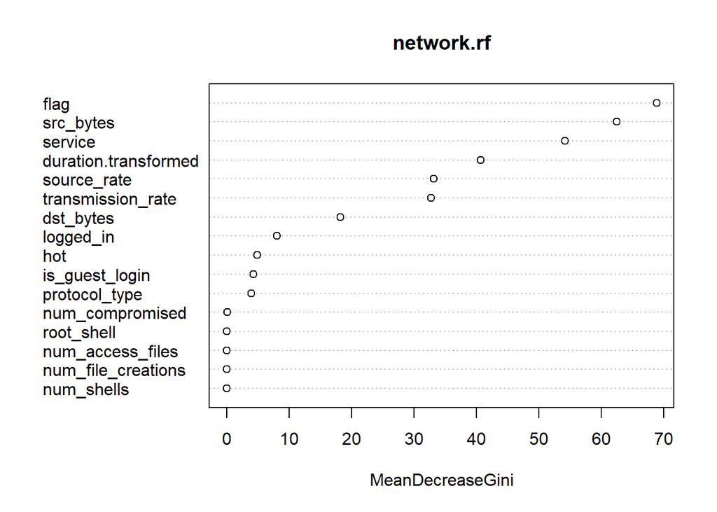

```r
#Importance Plot
varImpPlot(network.rf)
```

```r
#Create data frame of Importance values
importance.values <- data.frame(network.rf$importance)

#Mean Decrease Gini Data Frame
gini.index <- data.frame(names = c(rownames(network.rf$importance)), MeanDecreaseGini = c(importance.values$MeanDecreaseGini))

#Ordered Mean Decrease Gini
gini.index <- arrange(gini.index, -MeanDecreaseGini)
gini.index
```

```
##                   names MeanDecreaseGini
## 1                  flag      68.82503023
## 2             src_bytes      62.49293237
## 3               service      54.14130942
## 4  duration.transformed      40.71424229
## 5           source_rate      33.16074697
## 6     transmission_rate      32.77037324
## 7             dst_bytes      18.19729944
## 8             logged_in       8.08164469
## 9                   hot       4.92695002
## 10       is_guest_login       4.26749175
## 11        protocol_type       3.98415575
## 12      num_compromised       0.13613108
## 13           root_shell       0.06895272
## 14     num_access_files       0.04467480
## 15   num_file_creations       0.00599214
## 16           num_shells       0.00370903
```

*Next, we created a variable importance plot of our fitted random forest model. From the plot above, flag is the most important variable selected by random forest. In fact, the top 4 most important variables include flag, source bytes, service, and duration with the following mean decrease Gini values:68.8250302,62.4929324, 54.1413094, 40.7142423.*

*A higher decrease in Gini means greater node purity. A higher decrease in Gini results from a particular variable that is able to better partition the data into defined classes. From the plot and data above, num_shells, num_file_creations, num_access_files, root_shell, and num_compromised have a gini index close to 0, and therefore, they are trivial variables in terms of classifying intrusions.*

### Logistic Lasso

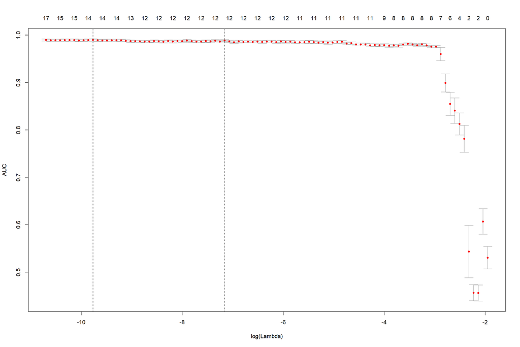

```r
#http://cs229.stanford.edu/proj2012/ChoiParkSeo-LassoInCategoricalData.pdf: cite

#Fit logistic lasso to train data
logit.train.x <- model.matrix(is_intrusion~., network.train)[,-1]
logit.train.y <- network.train$is_intrusion
lasso.network <- glmnet(logit.train.x,logit.train.y, family = "binomial", alpha = 1)

#Performing K-fold cross validation on sequence of model fits
network.lasso.cv <- cv.glmnet(logit.train.x,logit.train.y, family = "binomial", alpha = 1, type.measure = "auc")

#CV error curves
plot(network.lasso.cv)
```

```r
#Index of the two Lambdas
lambda.min.index <- which(network.lasso.cv$lambda == network.lasso.cv$lambda.min)
lambda.1se.index <- which(network.lasso.cv$lambda == network.lasso.cv$lambda.1se)

#Number of non-zero coefficients:
  #Lambda min
num.lambda.min <- network.lasso.cv$nzero[lambda.min.index]
  #Lambda 1-SE
num.lambda.1se <- network.lasso.cv$nzero[lambda.1se.index]

#AUC Values:
  #Lambda min
lambda.min.auc <- network.lasso.cv$cvm[lambda.min.index]
  #Lambda 1-SE
lambda.1se.auc <- network.lasso.cv$cvm[lambda.1se.index]
```

*The second model we fit to our train data was logistic lasso. Logistic lasso is a method that performs variable selection. In order to determine the best model size, we performed 10 fold cross validation. As seen from the plot above, 10 fold cross validation returns several lambda values which include the minimum lambda value of 0.0000573 and the lambda value of 0.0007759 which is associated with the 1-Standard Error rule. The difference between the two lambda values is that the minimum lambda value has a higher AUC than the 1-SE lambda value.*

*However, while the AUC of the minimum lambda value is higher and better than the AUC of the 1-SE lambda value, we chose the lambda that corresponds to the 1-SE rule. This is because the lambda that corresponds to the 1-SE rule reduces the complexity of our model from 14 to 12 variables while maintaining a relatively similar AUC value. The AUC of the minimum lambda value is 0.9897614 and the AUC of the 1-SE lambda value is 0.9885628. Therefore, the AUC of both the curves are relatively close.*

```r
#12 Coefficients for 1se model not including the intercept
coef.1se.12 <- coef(network.lasso.cv, s = network.lasso.cv$lambda[lambda.1se.index])
nonzero.coefs.12 <- rownames(coef.1se.12)[which(coef.1se.12 != 0)]
nonzero.coefs.12[-1]
```

```
##  [1] "servicedomain_u" "serviceftp"      "serviceftp_data"
##  [4] "serviceprivate"  "flagRSTR"        "flagS0"
##  [7] "flagS3"          "src_bytes"       "source_rate"
## [10] "hot"             "logged_in"       "is_guest_login"
```

*The 12 predictors that were selected by logistic lasso corresponding to the 1 standard error lambda value are listed above.*

```r
#Predict onto test data
logit.test.x <- model.matrix(is_intrusion~., network.test)[,-1]
lasso.prob <- predict(lasso.network, logit.test.x, type = "response", s = lasso.network$lambda[lambda.1se.index])

#Creating ROC curve variables for logistic lasso
roc.lasso <- roc(network.test$is_intrusion, lasso.prob)

#Confusion Matrix
classMetrics(lasso.prob, network.test$is_intrusion, cutoff , type = "all")
```

```
## $conf.mat
##          observed
## predicted   0   1
##         0 501   0
##         1  33  66
##
## $perf
##                 value
## accuracy    0.9450000
## sensitivity 1.0000000
## specificity 0.9382022
## ppv         0.6666667
## npv         1.0000000
## precision   0.6666667
## recall      1.0000000
```

*After selecting the best lambda value to use, we predicted our fitted logistic lasso onto the test data. Using the same cutoff we used on the Random Forest model, we obtained the confusion matrix above. By observing the confusion matrix above, the false negatives we obtained were 0 while the false positives we obtained were 33. Similar to random forest, logistic lasso was able to detect all of the more costly false negatives, and even had a similar sensitivity of 1. At the same cutoff value, random forest and logistic lasso have the same sensitivity. On the other hand, random forest outperforms logistic lasso because random forest has a higher specificity value. In this case, the specificity value of logistic lasso is 0.9382022.*

### Naive Bayes

```r
#Naive Bayes on the train data
network.nb <- NaiveBayes(is_intrusion~., data = network.train, usekernel = TRUE)

#Predict Naive Bayes on the test data
nb.probs <- predict(network.nb,newdata = network.test)
nb.posterior <- nb.probs$posterior[,2]

#Creating Roc Curve variables for naive bayes
roc.nb <- roc(network.test$is_intrusion, nb.posterior)


#Confusion Matrix of test data & Performance Values
classMetrics(nb.posterior, network.test$is_intrusion, cutoff)
```

```
## $conf.mat
##          observed
## predicted   0   1
##         0 530  60
##         1   4   6
##
## $perf
##                  value
## accuracy    0.89333333
## sensitivity 0.09090909
## specificity 0.99250936
## ppv         0.60000000
## npv         0.89830508
## precision   0.60000000
## recall      0.09090909
```

*The last model we used to determine the number of intrusions is Naive Bayes. At the same cutoff value used for the other two models, Naive Bayes performed the worst. The number of false negatives is 60 which is much higher than the other two models. This indicates that Naive Bayes predicted 60 sessions as being not an intrusion when those sessions were actually intrusions.*

*On the other hand, the number of false positives were much lower then the other models. However, since false negatives are much costlier in intrusion detections, Naive Baives is a poor classifier. Furthermore, the sensitivity, as seen above, is very poor as well.*

### ROC Curves

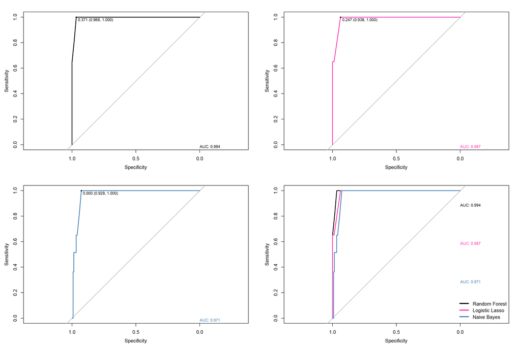

```r
#OVerlaying Roc Curves
par(mfrow = c(2,2))
plot(roc.rf, print.auc = TRUE, print.auc.x = 0, print.auc.y = 0, print.thres = TRUE)
plot(roc.lasso, col = "maroon1", print.auc = TRUE, print.auc.x = 0, print.auc.y = 0, print.thres = TRUE)
plot(roc.nb, col = "steelblue", print.auc = TRUE, print.auc.x = 0, print.auc.y = 0, print.thres = TRUE)

plot(roc.rf, print.auc = TRUE, print.auc.x = 0, print.auc.y = 0.9)
plot(roc.lasso, col = "maroon1", add = TRUE, print.auc = TRUE, print.auc.x = 0, print.auc.y = 0.6)
plot(roc.nb, col = "steelblue", add = TRUE,print.auc = TRUE, print.auc.x = 0, print.auc.y = 0.3)
legend(x = "bottomright", col = c("black", "maroon1", "steelblue"), lwd = 3, legend = c("Random Forest", "Logistic Lasso", "Naive Bayes"), bty = "n")
```

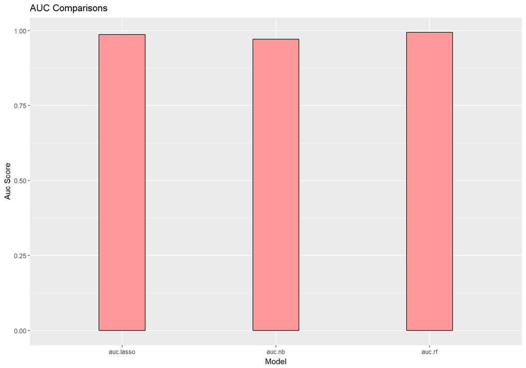

```r
#Auc Value
auc.rf <- roc.rf$auc
auc.nb <- roc.nb$auc
auc.lasso <- roc.lasso$auc


#Plot of Auc
model <- c("auc.rf", "auc.nb", "auc.lasso")
auc.score <- c(auc.rf, auc.nb, auc.lasso)
auc.df <- data.frame(model, auc.score)

#Plot of the AUC
ggplot(auc.df, aes(x = model, y = auc.score, width = 0.3)) + geom_bar(stat = "identity", fill = "#FF9999", colour = "black") + xlab("Model") + ylab("Auc Score") + ggtitle(label = "AUC Comparisons")
```

*From the ROC curves above, we were able to determine the optimal cutoff point for each model. From the overlay of the ROC curves, we noticed that while sensitivity of 1 could be achieved by all three models, we needed to measure their performance on a similar scale using the same cutoff. At the cutoff 0.371, Random Forest was able to achieve the highest specificity and sensitivity. Therefore, we measured all three models at this cutoff value to see if any of the other two models performed better.*

## *Clustering Types of Network Intrusions*

**Identifying different types of intrusions**

*After successfully classifying network sessions as benign and intrusions, we now move on to understanding patterns of intrusions in our system log. The system log is a set of data comprising of numerical and factor attributes. Clustering on factor attributes is not a straight forward task and hence we first convert our system log into a matrix using the `matrix.model`. The matrix is then scaled for clustering tasks to be carried out.*

*The two best known clustering methods are Hierarchical clustering and K-means clustering. We will apply both the clustering techniques to the system log which we have been analysing.*

```r
#getting data ready for clustering of intrusions

#get ONLY intrusion data
network.intrusion <- filter(network.reduced, network.reduced$is_intrusion==1)

#dropping columns
network.intrusion <- dplyr::select(network.intrusion, c(-num_compromised, -root_shell, -num_file_creations, -num_shells, -num_access_files))

#dropping levels
network.intrusion$service <- droplevels(network.intrusion$service)

network.intrusion$flag <- droplevels(network.intrusion$flag)

network.intrusion$protocol_type <- droplevels(network.intrusion$protocol_type)

#convert network.intrusion to a matrix
network.intrusion.num <- model.matrix(is_intrusion~., network.intrusion)[,-1]

#scale the matrix for clustering
num<-scale(network.intrusion.num)
```

### Hierarchical Clustering

*In hierarchical clustering, we do not know the numbers of cluster we want. With hierarchical clustering the end result is a tree-like structure called dendogram. The dendogram allows us to view the clusters in a tree like structure with all 1 to n observations.*

```r
#distances for Hierarchical clustering
data.dist=dist(num)
```

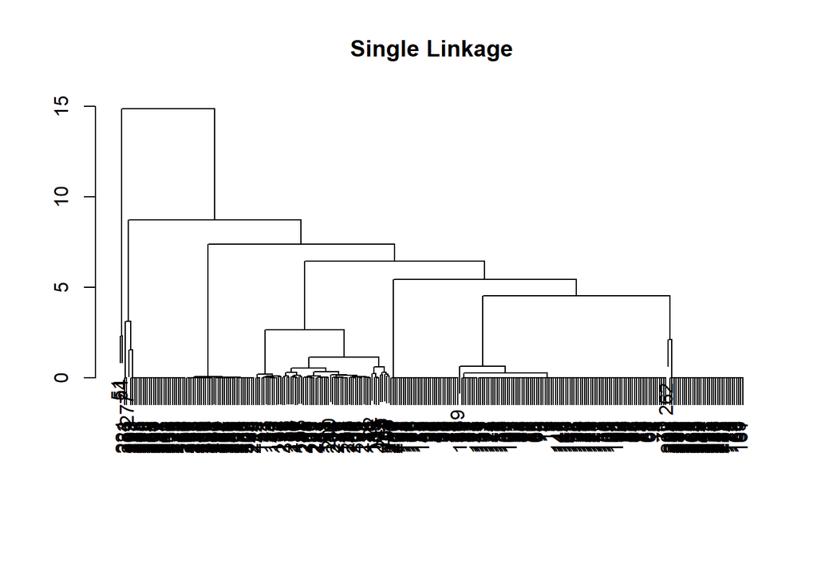

```r
#Single Linkage Hierarchical Clustering
hc.single <- hclust(data.dist)
plot(hc.single, main=" Single Linkage ", xlab="", sub ="", ylab ="")
```

```r
cutree(hc.single, 4)
```

```
##   1   2   3   4   5   6   7   8   9  10  11  12  13  14  15  16  17  18
##   1   1   1   1   1   1   1   1   1   1   1   1   1   1   1   1   1   1
##  19  20  21  22  23  24  25  26  27  28  29  30  31  32  33  34  35  36
##   1   1   1   1   1   1   1   1   1   1   1   1   1   1   1   1   1   1
##  37  38  39  40  41  42  43  44  45  46  47  48  49  50  51  52  53  54
##   1   1   1   1   1   1   1   1   1   1   1   1   1   1   2   1   1   2
##  55  56  57  58  59  60  61  62  63  64  65  66  67  68  69  70  71  72
##   1   1   1   1   1   1   1   1   1   1   1   1   1   1   1   1   1   1
##  73  74  75  76  77  78  79  80  81  82  83  84  85  86  87  88  89  90
##   1   1   1   1   1   1   1   1   1   1   1   1   1   1   1   1   1   1
##  91  92  93  94  95  96  97  98  99 100 101 102 103 104 105 106 107 108
##   1   1   1   1   1   1   1   1   1   1   1   1   1   1   1   1   1   1
## 109 110 111 112 113 114 115 116 117 118 119 120 121 122 123 124 125 126
##   1   1   1   1   1   1   1   1   1   1   1   1   1   1   1   1   1   1
## 127 128 129 130 131 132 133 134 135 136 137 138 139 140 141 142 143 144
```

[output cut: 19 more lines]

#### Complete Linkage Clustering

*In Complete Linkage Clustering, we compute the maximal inter-cluster dissimilarity. We compute all pairwise dissimilarities between the observations in say cluster A and the observations in cluster B, and record the largest of these dissimilarities.*

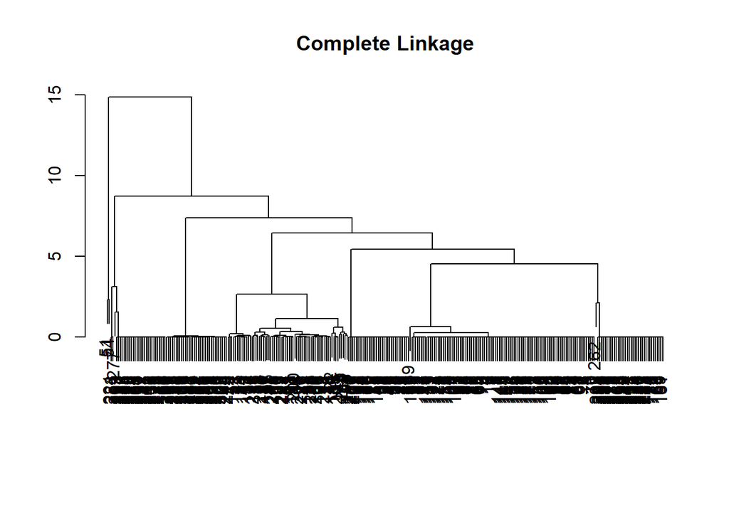

```r
#Complete Linkage Hierarchical Clustering
hc.complete <- hclust(data.dist)
plot(hc.complete, main='Complete Linkage', xlab ="", sub ="", ylab ="")
```

```r
cutree(hc.complete, 4)
```

```
##   1   2   3   4   5   6   7   8   9  10  11  12  13  14  15  16  17  18
##   1   1   1   1   1   1   1   1   1   1   1   1   1   1   1   1   1   1
##  19  20  21  22  23  24  25  26  27  28  29  30  31  32  33  34  35  36
##   1   1   1   1   1   1   1   1   1   1   1   1   1   1   1   1   1   1
##  37  38  39  40  41  42  43  44  45  46  47  48  49  50  51  52  53  54
##   1   1   1   1   1   1   1   1   1   1   1   1   1   1   2   1   1   2
##  55  56  57  58  59  60  61  62  63  64  65  66  67  68  69  70  71  72
##   1   1   1   1   1   1   1   1   1   1   1   1   1   1   1   1   1   1
##  73  74  75  76  77  78  79  80  81  82  83  84  85  86  87  88  89  90
##   1   1   1   1   1   1   1   1   1   1   1   1   1   1   1   1   1   1
##  91  92  93  94  95  96  97  98  99 100 101 102 103 104 105 106 107 108
##   1   1   1   1   1   1   1   1   1   1   1   1   1   1   1   1   1   1
## 109 110 111 112 113 114 115 116 117 118 119 120 121 122 123 124 125 126
##   1   1   1   1   1   1   1   1   1   1   1   1   1   1   1   1   1   1
## 127 128 129 130 131 132 133 134 135 136 137 138 139 140 141 142 143 144
```

[output cut: 19 more lines]

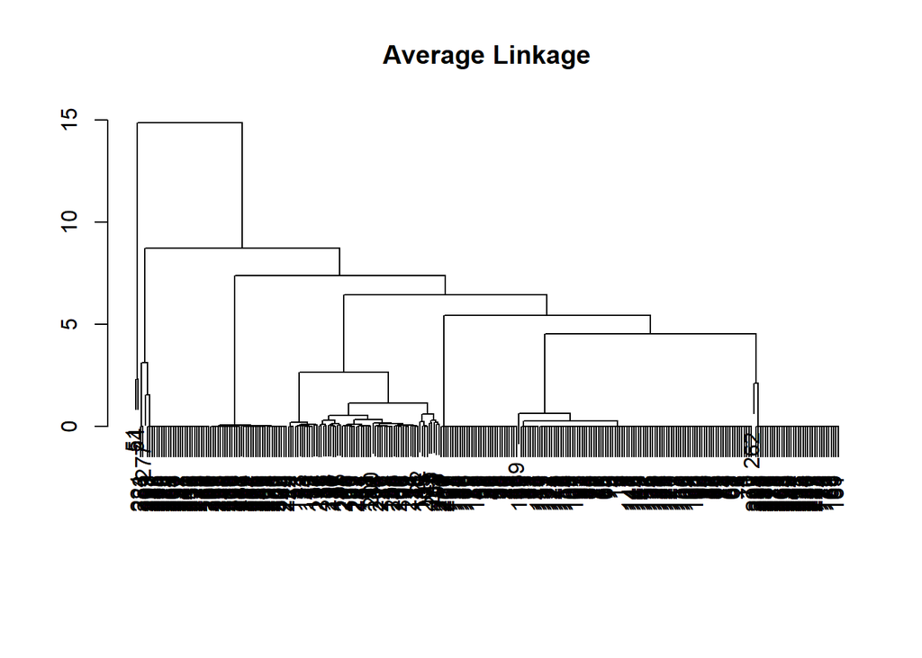

```r
#Average Linkage Hierarchical Clustering
hc.average <- hclust(data.dist)
plot(hc.average,  main=" Average Linkage ", xlab ="", sub ="", ylab ="")
```

```r
cutree(hc.average, 4)
```

```
##   1   2   3   4   5   6   7   8   9  10  11  12  13  14  15  16  17  18
##   1   1   1   1   1   1   1   1   1   1   1   1   1   1   1   1   1   1
##  19  20  21  22  23  24  25  26  27  28  29  30  31  32  33  34  35  36
##   1   1   1   1   1   1   1   1   1   1   1   1   1   1   1   1   1   1
##  37  38  39  40  41  42  43  44  45  46  47  48  49  50  51  52  53  54
##   1   1   1   1   1   1   1   1   1   1   1   1   1   1   2   1   1   2
##  55  56  57  58  59  60  61  62  63  64  65  66  67  68  69  70  71  72
##   1   1   1   1   1   1   1   1   1   1   1   1   1   1   1   1   1   1
##  73  74  75  76  77  78  79  80  81  82  83  84  85  86  87  88  89  90
##   1   1   1   1   1   1   1   1   1   1   1   1   1   1   1   1   1   1
##  91  92  93  94  95  96  97  98  99 100 101 102 103 104 105 106 107 108
##   1   1   1   1   1   1   1   1   1   1   1   1   1   1   1   1   1   1
## 109 110 111 112 113 114 115 116 117 118 119 120 121 122 123 124 125 126
##   1   1   1   1   1   1   1   1   1   1   1   1   1   1   1   1   1   1
## 127 128 129 130 131 132 133 134 135 136 137 138 139 140 141 142 143 144
```

[output cut: 19 more lines]

*Complete linkage improves on Single linkage and does not suffer from chaining, but gets hit with crowding. Here, the farthest two points are considered and hence the clusters tend to be compact but not spread out.*

*Average linkage handles the drawbacks of the single and complete linkage approaches but it has its own problems. The cuts in average linkages cannot be interpreted easily. The clusters can also change if we apply a monotone increasing transformation to our dissimilarity measure.*

#### Correlation between different linkage clusters

```r
#visualizing correlations between hierarchical clustering when done via different distance methods: single, complete and linkage
hclust_methods <- c("single", "complete", "average")
network_dendlist <- dendlist()

for(i in seq_along(hclust_methods)) {
   hc_network <- hclust(data.dist, method = hclust_methods[i])
   network_dendlist <- dendlist(network_dendlist, as.dendrogram(hc_network))
}

names(network_dendlist) <- hclust_methods
network_dendlist
```

```
## $single
## 'dendrogram' with 2 branches and 300 members total, at height 12.26798
##
## $complete
## 'dendrogram' with 2 branches and 300 members total, at height 14.85493
##
## $average
## 'dendrogram' with 2 branches and 300 members total, at height 13.39727
##
## attr(,"class")
## [1] "dendlist"
```

```r
network_dendlist_cor <- cor.dendlist(network_dendlist)
network_dendlist_cor
```

```
##             single  complete   average
## single   1.0000000 0.9768911 0.9899399
## complete 0.9768911 1.0000000 0.9896156
## average  0.9899399 0.9896156 1.0000000
```

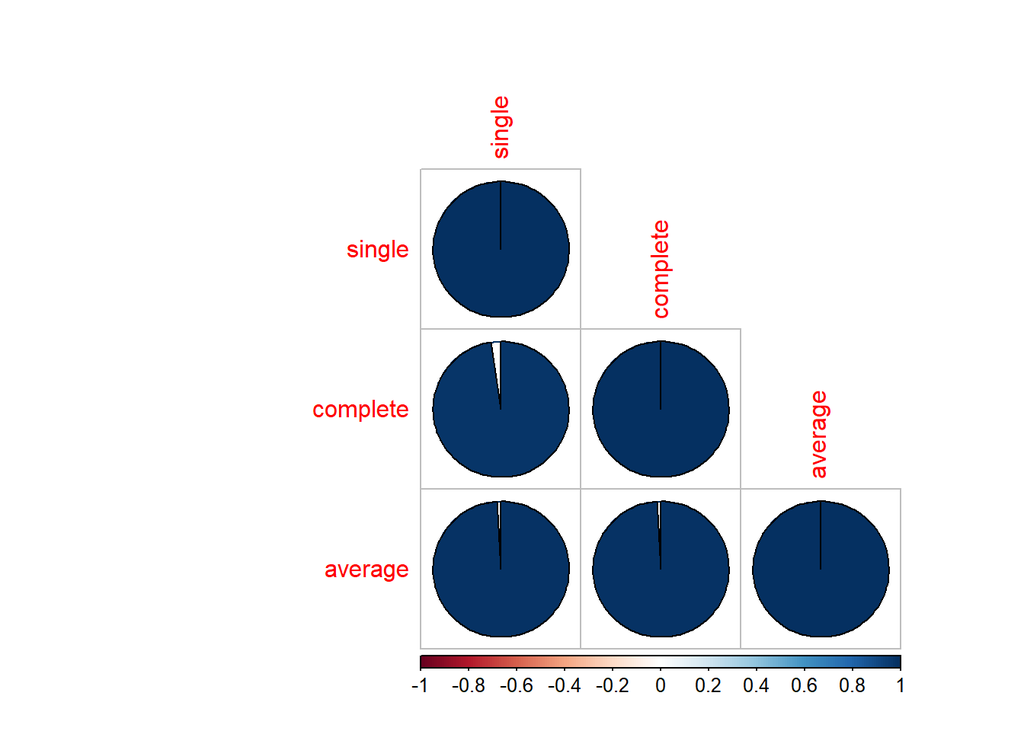

```r
#plotting the correlation between different hierarchical clustering distances
corrplot::corrplot(network_dendlist_cor, "pie", "lower")
```

*In the above correlation plots, we can see that the three linkage methods perform similarly and cannot be differentiated much.*

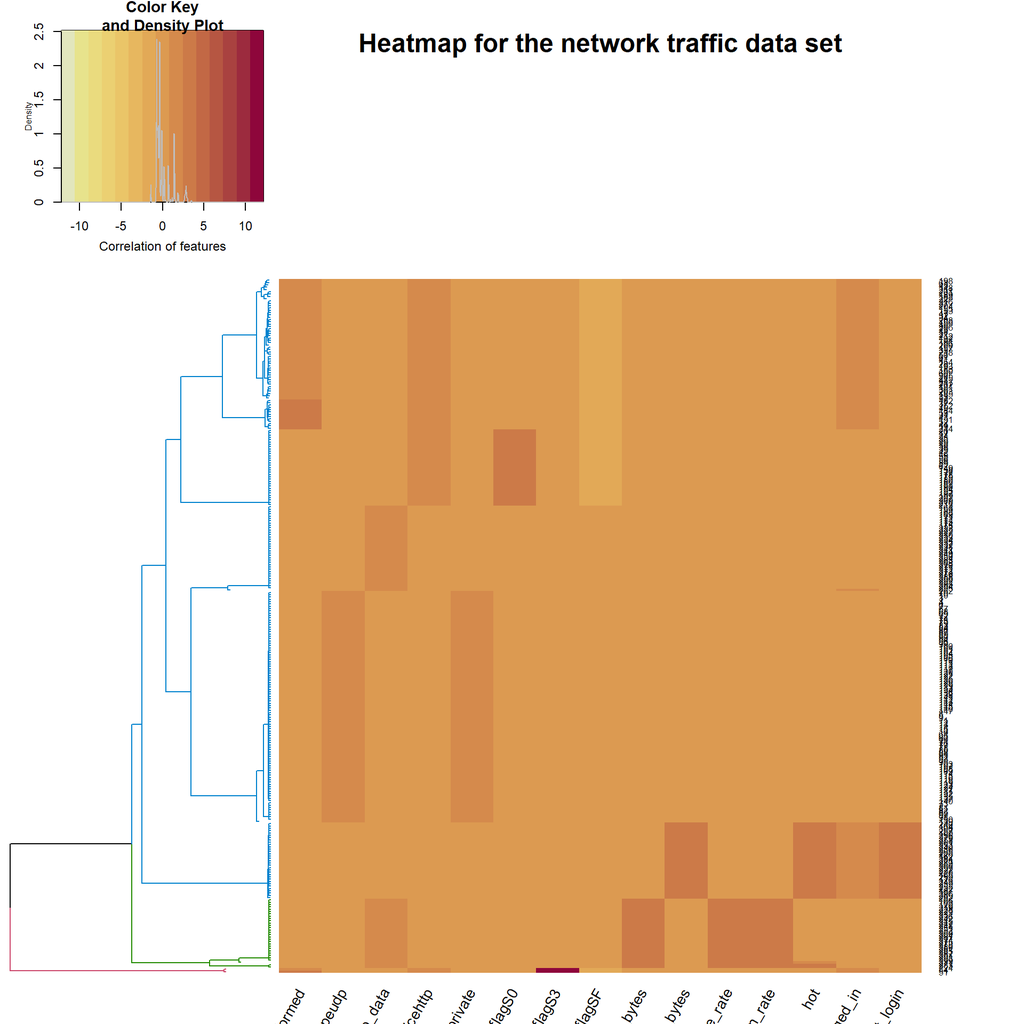

```r
#heatmap for the heirarchical clustering
some_col_func <- function(n) rev(colorspace::heat_hcl(n, c = c(80, 30), l = c(30, 90), power = c(1/5, 1.5)))
dend = as.dendrogram(hc_network)
dend <- color_branches(dend, k=3)
dend <- hang.dendrogram(dend,hang_height=0.1)
dend <- set(dend, "labels_cex", 0.5)

par(mar = rep(0,4))

gplots::heatmap.2(num,
          main = "Heatmap for the network traffic data set",
          srtCol = 60,
          dendrogram = "row",
          Rowv = dend,
          Colv = "NA", # this to make sure the columns are not ordered
          trace="none",
          margins =c(3,6),
          key.xlab = "Correlation of features",
          denscol = "grey",
          density.info = "density",
          col = some_col_func
         )
```

*The heatmap is a good method of viewing the contribution of the features in the data set that contribute towards the different kinds of intrusions.*

*The x-axis contains the features that are used for classifying the different kinds of intrusions present in the data. The darker shades suggest that the feature is highly correlated to the feature.*

*For example, from the heatmap it can be seen that flagS3 is highly correlated to the first cluster as the color is the darkest shade in the entire heatmap.*

### Gower Distance Hierarchical Clustering

*We try improving the clustering better by using Gower distances in the next few hierarchical clustering steps. Gower distances work well for mixed datasets which contain factor and numeric values as attributes.*

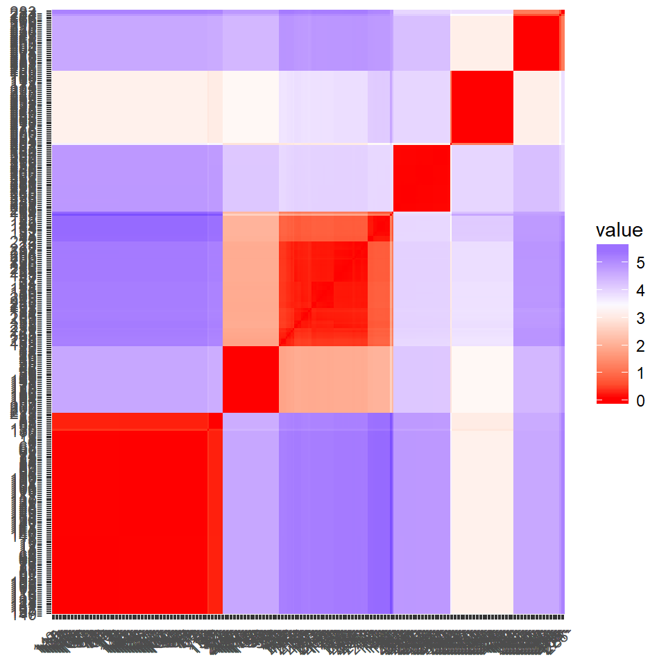

```r
#http://www.sthda.com/english/articles/26-clustering-basics/86-clustering-distance-measures-essentials/ : Citation

#Gower distance Hierarchical clustering
gower.mat <- as.matrix(daisy(num, metric = "gower"))

#getting the distances in the Gower matrix
d.gower <- dist(gower.mat)

#displaying the Gower distance matrix
fviz_dist(d.gower)
```

*The function daisy() is used to get the Gower distances, in data where there is a mixture of categorical and numerical values in features.*

*The fviz_dist() function from the factoextra package is used above to plot the Gower distance. The color levels are proportional to the value of the dissimilarity between observations: pure red if dist(xi,xj)=0 and pure blue corresponds to the highest value of computed Gower distance. Objects belonging to the same cluster are displayed in consecutive order.*

*We now proceed with single, complete and average linkage hierarchical clustering using the Gower distance that we have computed.*

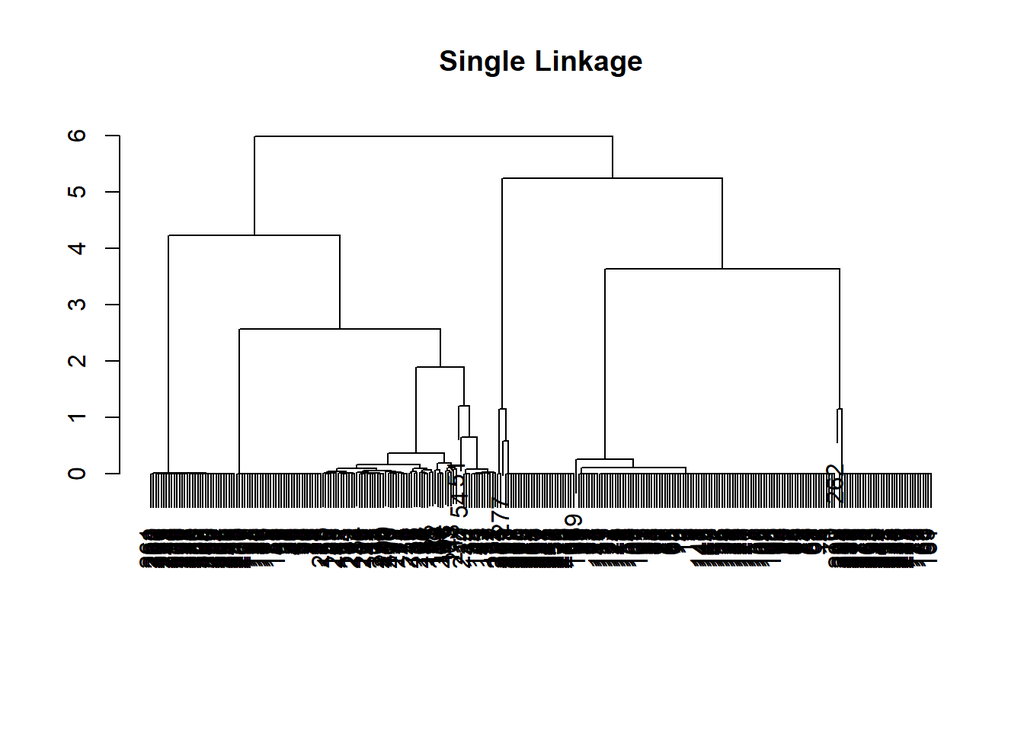

```r
#Single Linkage Hierarchical Clustering
hc.gower.single <- hclust(d.gower)
plot(hc.gower.single, main=" Single Linkage ", xlab="", sub ="", ylab ="")
```

```r
cutree(hc.gower.single, 4)
```

```
##   1   2   3   4   5   6   7   8   9  10  11  12  13  14  15  16  17  18
##   1   1   1   1   1   1   1   1   1   1   1   1   1   1   1   1   2   2
##  19  20  21  22  23  24  25  26  27  28  29  30  31  32  33  34  35  36
##   2   2   2   2   2   2   2   2   2   2   2   2   2   2   2   2   2   2
##  37  38  39  40  41  42  43  44  45  46  47  48  49  50  51  52  53  54
##   2   2   2   2   2   2   2   2   2   2   2   2   2   2   2   2   2   2
##  55  56  57  58  59  60  61  62  63  64  65  66  67  68  69  70  71  72
##   2   2   2   2   2   2   2   2   2   1   1   1   1   1   1   1   1   1
##  73  74  75  76  77  78  79  80  81  82  83  84  85  86  87  88  89  90
##   1   1   1   1   1   1   1   1   1   1   1   1   1   1   1   1   1   1
##  91  92  93  94  95  96  97  98  99 100 101 102 103 104 105 106 107 108
##   1   1   1   1   1   1   1   1   1   1   1   1   1   1   1   1   1   1
## 109 110 111 112 113 114 115 116 117 118 119 120 121 122 123 124 125 126
##   1   1   1   1   1   1   1   1   1   1   1   1   1   1   1   1   1   1
## 127 128 129 130 131 132 133 134 135 136 137 138 139 140 141 142 143 144
```

[output cut: 19 more lines]

#### Complete Linkage Clustering using Gower Distance

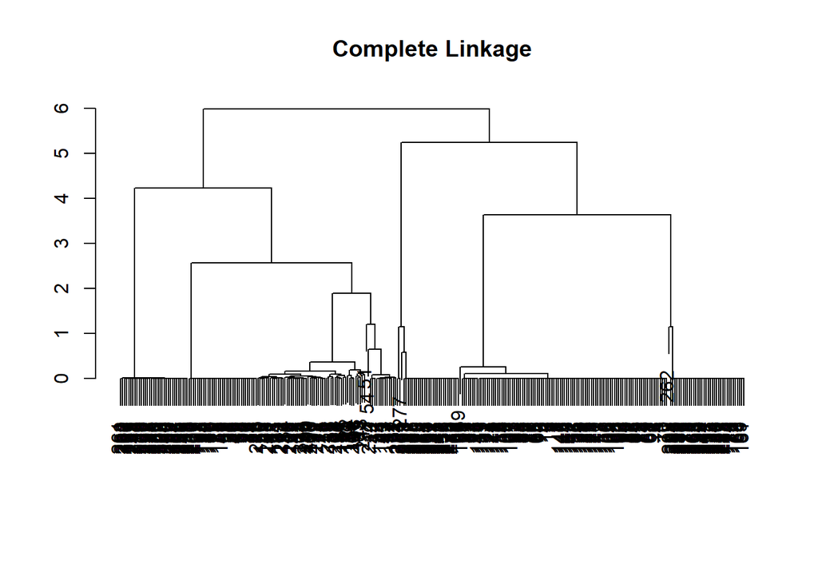

```r
#Complete Linkage Hierarchical Clustering
hc.gower.complete <- hclust(d.gower)
plot(hc.gower.complete, main='Complete Linkage', xlab ="", sub ="", ylab ="")
```

```r
cutree(hc.gower.complete, 4)
```

```
##   1   2   3   4   5   6   7   8   9  10  11  12  13  14  15  16  17  18
##   1   1   1   1   1   1   1   1   1   1   1   1   1   1   1   1   2   2
##  19  20  21  22  23  24  25  26  27  28  29  30  31  32  33  34  35  36
##   2   2   2   2   2   2   2   2   2   2   2   2   2   2   2   2   2   2
##  37  38  39  40  41  42  43  44  45  46  47  48  49  50  51  52  53  54
##   2   2   2   2   2   2   2   2   2   2   2   2   2   2   2   2   2   2
##  55  56  57  58  59  60  61  62  63  64  65  66  67  68  69  70  71  72
##   2   2   2   2   2   2   2   2   2   1   1   1   1   1   1   1   1   1
##  73  74  75  76  77  78  79  80  81  82  83  84  85  86  87  88  89  90
##   1   1   1   1   1   1   1   1   1   1   1   1   1   1   1   1   1   1
##  91  92  93  94  95  96  97  98  99 100 101 102 103 104 105 106 107 108
##   1   1   1   1   1   1   1   1   1   1   1   1   1   1   1   1   1   1
## 109 110 111 112 113 114 115 116 117 118 119 120 121 122 123 124 125 126
##   1   1   1   1   1   1   1   1   1   1   1   1   1   1   1   1   1   1
## 127 128 129 130 131 132 133 134 135 136 137 138 139 140 141 142 143 144
```

[output cut: 19 more lines]

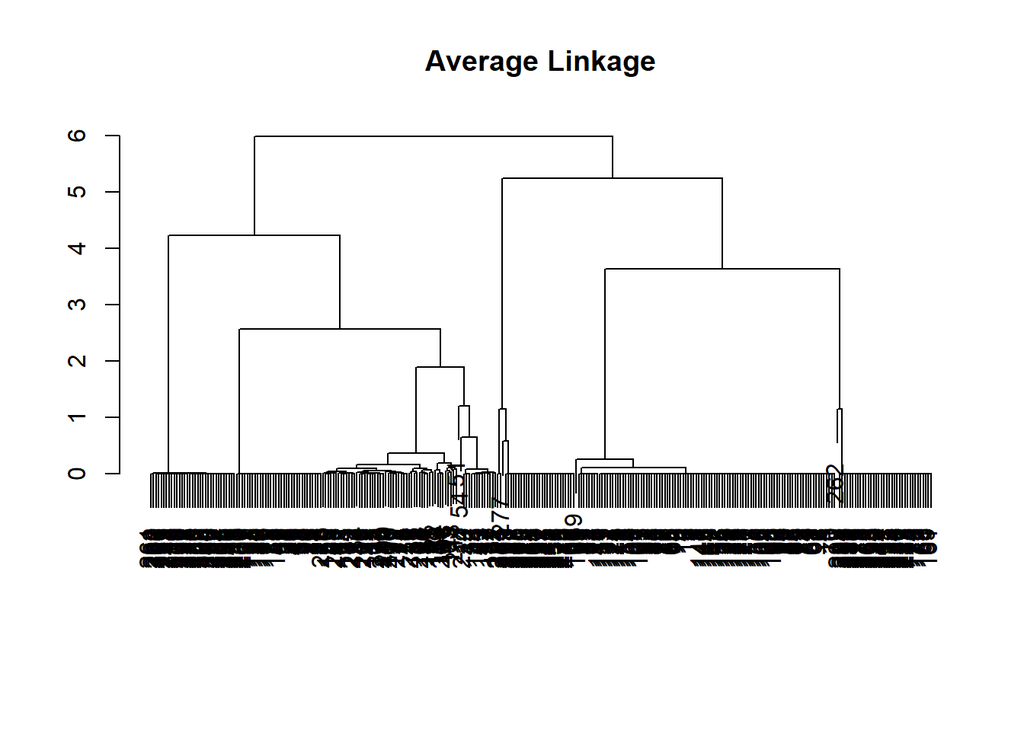

```r
#Average Linkage Hierarchical Clustering
hc.gower.average <- hclust(d.gower)
plot(hc.gower.average,  main=" Average Linkage ", xlab ="", sub ="", ylab ="")
```

```r
cutree(hc.gower.average, 4)
```

```
##   1   2   3   4   5   6   7   8   9  10  11  12  13  14  15  16  17  18
##   1   1   1   1   1   1   1   1   1   1   1   1   1   1   1   1   2   2
##  19  20  21  22  23  24  25  26  27  28  29  30  31  32  33  34  35  36
##   2   2   2   2   2   2   2   2   2   2   2   2   2   2   2   2   2   2
##  37  38  39  40  41  42  43  44  45  46  47  48  49  50  51  52  53  54
##   2   2   2   2   2   2   2   2   2   2   2   2   2   2   2   2   2   2
##  55  56  57  58  59  60  61  62  63  64  65  66  67  68  69  70  71  72
##   2   2   2   2   2   2   2   2   2   1   1   1   1   1   1   1   1   1
##  73  74  75  76  77  78  79  80  81  82  83  84  85  86  87  88  89  90
##   1   1   1   1   1   1   1   1   1   1   1   1   1   1   1   1   1   1
##  91  92  93  94  95  96  97  98  99 100 101 102 103 104 105 106 107 108
##   1   1   1   1   1   1   1   1   1   1   1   1   1   1   1   1   1   1
## 109 110 111 112 113 114 115 116 117 118 119 120 121 122 123 124 125 126
##   1   1   1   1   1   1   1   1   1   1   1   1   1   1   1   1   1   1
## 127 128 129 130 131 132 133 134 135 136 137 138 139 140 141 142 143 144
```

[output cut: 19 more lines]

*The Gower distance Hierarchical clustering seems to perform better than the Euclidean distance based Hierarchical clustering. But it is still not giving us a consistent picture of the types of intrusions that are present in the data.*

*In our pursuit of getting better clusters to identify different types of intrusions, we use K-means clustering next.*

### K-means Clustering

*In K-means clustering, we seek to partition the observations into a pre-specified number of clusters. It is tricky to estimate the number of clusters from the onset, but K-means has been observed to perform well at clustering tasks with various mixtures of data.*

```r
#k-means clustering
km.out=kmeans(num, 4, nstart = 50)

#k-means clustering results
km.out
```

```
## K-means clustering with 4 clusters of sizes 100, 30, 33, 137
##
## Cluster means:
##   duration.transformed protocol_typeudp serviceftp_data servicehttp
## 1           0.87160764       -0.7059273      -0.5353458   1.4118546
## 2          -0.05701459       -0.7059273       1.8617250  -0.7059273
## 3          -0.05293762       -0.7059273      -0.5353458  -0.7059273
## 4          -0.61097361        0.8398989       0.1120383  -0.7059273
##   serviceprivate     flagS0      flagS3     flagSF   src_bytes   dst_bytes
## 1     -0.7059273  0.7019502  0.16357308 -1.4118546 -0.03075308 -0.62064818
## 2     -0.7059273 -0.3509751 -0.08178654  0.7059273  2.85948228 -0.62103147
## 3     -0.7059273 -0.3509751 -0.08178654  0.7059273 -0.48576049  2.64926692
## 4      0.8398989 -0.3509751 -0.08178654  0.7059273 -0.48670850 -0.04912443
##   source_rate transmission_rate        hot  logged_in is_guest_login
## 1  -0.3843473       -0.54788656 -0.3672127  0.7041866     -0.3509751
```

[output cut: 49 more lines]

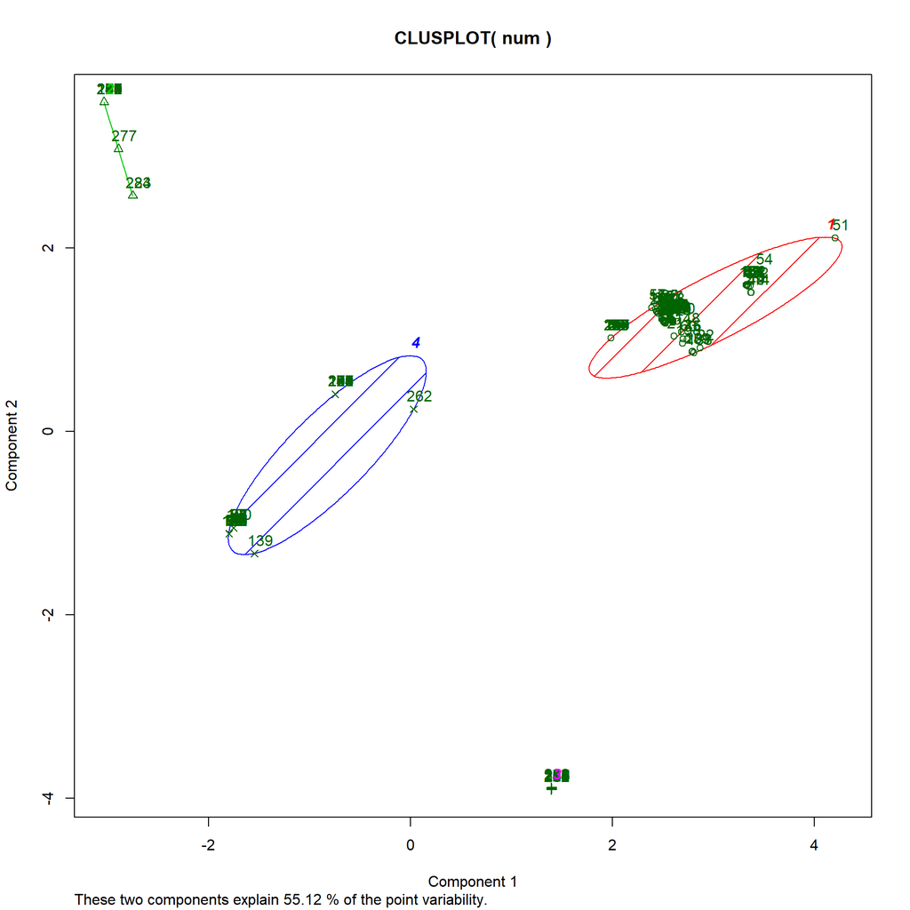

```r
#plotting the k-means clusters
clusplot(num, km.out$cluster, color=TRUE, shade=TRUE, labels=2, lines=0)
```

*The cluster plot above shows 4 clusters among the intrusions in the data. We have used a value of K=4 for the K-means clustering approach.*

*K-means clustering is a simple and elegant approach for partitioning a data set into K distinct, non-overlapping clusters. To perform K-means clustering, we must first specify the desired number of clusters K; then the K-means algorithm will assign each observation to exactly one of the K clusters.*

*The main idea behind K-means clustering is that a good clustering is one for which the within-cluster variation is as small as possible.*

*The K-means clustering works well for the network intrusion system log data and we are able to get 4 types of intrusions from the data.*

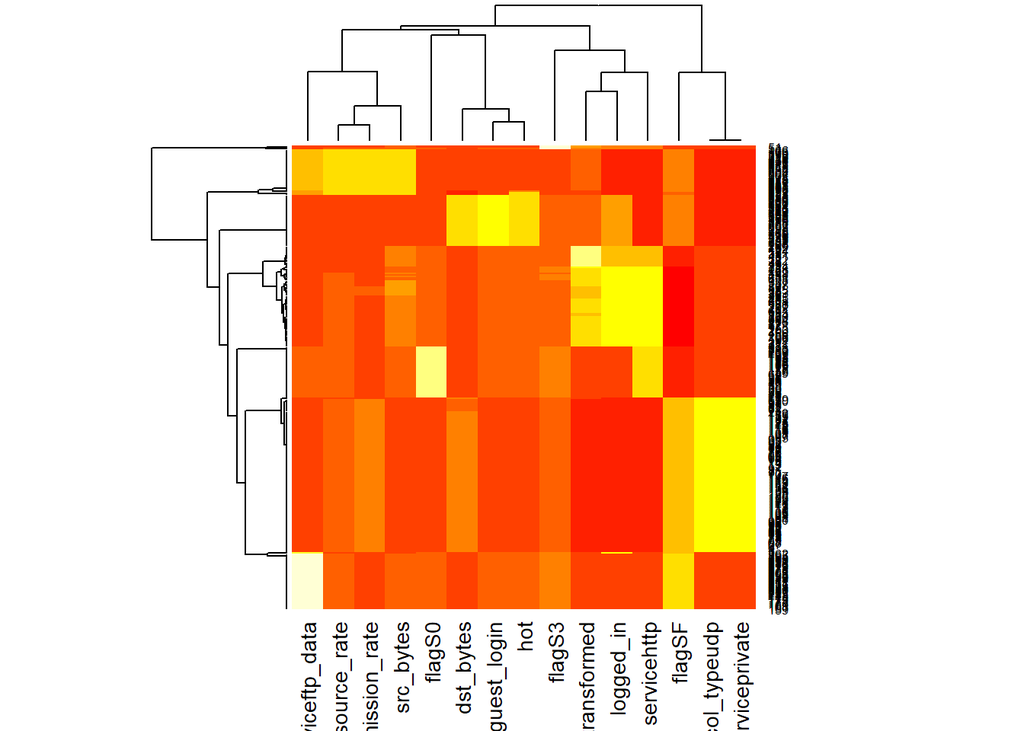

```r
#heatmap of clusters in the data
heatmap(num)
```

*The heatmap above gives a good idea of how the various features contribute to the 4 different clusters that we have achieved via K-means clustering.*

*By carefully studying the heatmap and applying domain knowledge of networks we have come up with 4 types of intrusions as follows:*

- *1. The first cluster comprising of `serviceftp_data`, `source_rate`, `transmission_rate` and `src_bytes` comprise a Denial of Service attack. This is usually done to prevent the users to access the server.*
- *2. The second cluster comprising of flagS0, dst_bytes, guest_login and hot comprise a User to Root hacking attack as the hot and guest_login attributes are associated with the clusters.*
- *3. The third cluster comprising of flagS3, duration_transformed, logged_in, servicehttp make a Probing attack. The flagS3 in networking terms shows that a connection was established but the destination closed it. This attack is usually to check for open ports to get through into the system.*
- *4. The fourth cluster comprising of flagSF, protocol_typeudp, serviceprivate is a R2L attack. An R2L attack is an unauthorized access from a remote machine.*

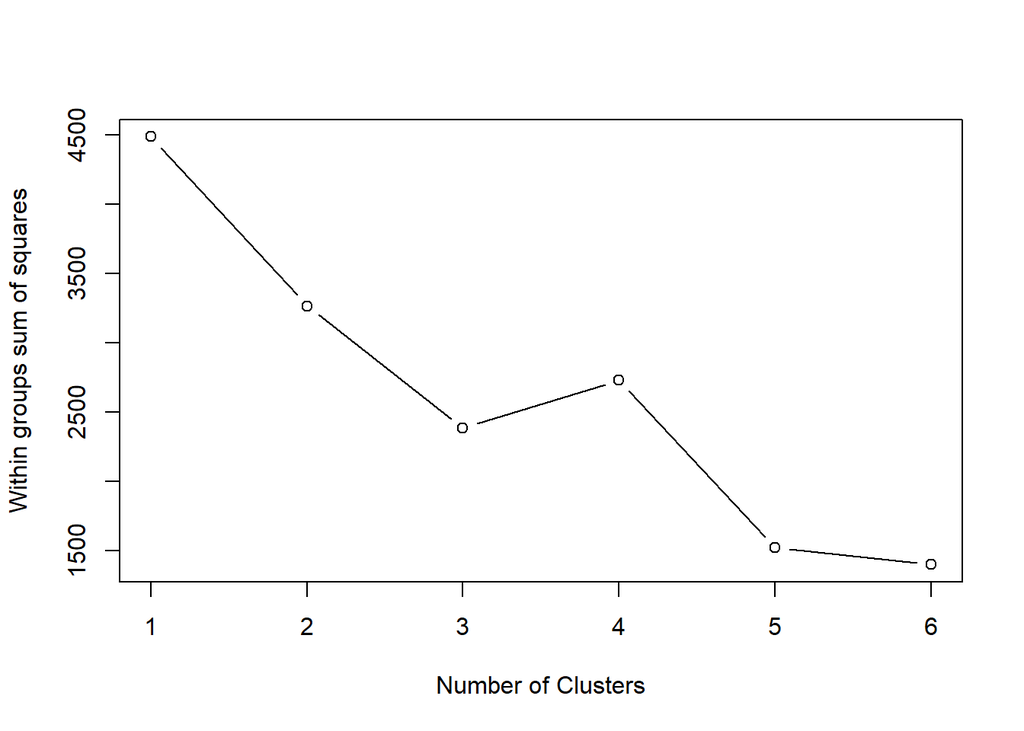

```r
#https://www.statmethods.net/advstats/cluster.html : Citation

# Determine number of clusters
wss <- (nrow(num)-1)*sum(apply(num,2,var))
for (i in 2:6) wss[i] <- sum(kmeans(num, centers=i)$withinss)
plot(1:6, wss, type="b", xlab="Number of Clusters",
  ylab="Within groups sum of squares")
```

## *Anomaly Detection*

**Developing and implementing a systematic approach to detect instances of intrusions in log files**

*From the above steps we were able to achieve classificatio of intrusions fron benign sessions and get different types of network intrusions as well. Now we explore the anomaly detection task.*

*Here we will be studying the various data points that are neither benign nor network intrusions, but should be analyzed for reducing risks and reducing costs of network intrusions in the bank network.*

```r
#anomaly detection

#https://cran.r-project.org/web/packages/anomalyDetection/vignettes/Introduction.html : citation for anomalyDetection package and steps

#state vector creation
tabulate_state_vector(network.reduced, 10)
```

```
## # A tibble: 299 x 97
##     auth domain_u dst_bytes_105 dst_bytes_145 dst_bytes_146 dst_bytes_147
##    <dbl>    <dbl>         <dbl>         <dbl>         <dbl>         <dbl>
##  1     0     0             0                0          0             0
##  2     0     0             0                0          1.00          0
##  3     0     0             0                0          0             0
##  4     0     1.00          0                0          0             0
##  5     0     2.00          0                0          0             0
##  6     0     0             0                0          0             0
##  7     0     0             1.00             0          0             0
##  8     0     4.00          0                0          2.00          0
##  9     0     6.00          0                0          0             1.00
## 10     0     1.00          0                0          0             0
## # ... with 289 more rows, and 91 more variables: dst_bytes_328 <dbl>,
## #   dst_bytes_330 <dbl>, dst_bytes_331 <dbl>, dst_bytes_332 <dbl>,
## #   dst_bytes_333 <dbl>, dst_bytes_42 <dbl>, dst_bytes_48 <dbl>,
## #   duration.transformed_1 <dbl>, duration.transformed_2 <dbl>,
## #   duration.transformed_281 <dbl>, duration.transformed_283 <dbl>,
## #   duration.transformed_3 <dbl>, duration.transformed_4 <dbl>,
## #   duration.transformed_5 <dbl>, duration.transformed_6 <dbl>,
## #   duration.transformed_806 <dbl>, duration.transformed_902 <dbl>, eco_i
## #   <dbl>, ecr_i <dbl>, finger <dbl>, ftp <dbl>, ftp_data <dbl>, hot_1
## #   <dbl>, hot_19 <dbl>, hot_2 <dbl>, hot_22 <dbl>, hot_25 <dbl>, hot_4
## #   <dbl>, hot_5 <dbl>, hot_6 <dbl>, http <dbl>, icmp <dbl>,
## #   is_guest_login_1 <dbl>, is_intrusion_1 <dbl>, logged_in_1 <dbl>, ntp_u
## #   <dbl>, num_access_files_1 <dbl>, num_access_files_2 <dbl>,
## #   num_access_files_5 <dbl>, num_compromised_1 <dbl>, num_compromised_4
## #   <dbl>, num_compromised_884 <dbl>, num_file_creations_1 <dbl>,
## #   num_shells_1 <dbl>, other <dbl>, pop_3 <dbl>, private <dbl>, REJ
## #   <dbl>, root_shell_1 <dbl>, RSTO <dbl>, RSTR <dbl>, S0 <dbl>, S3 <dbl>,
## #   SF <dbl>, smtp <dbl>, source_rate_1009.31672597865 <dbl>,
## #   source_rate_105 <dbl>, source_rate_12 <dbl>, source_rate_227 <dbl>,
## #   source_rate_299 <dbl>, source_rate_30 <dbl>, source_rate_42 <dbl>,
## #   source_rate_44 <dbl>, source_rate_46 <dbl>, source_rate_48 <dbl>,
## #   src_bytes_105 <dbl>, src_bytes_12 <dbl>, src_bytes_146 <dbl>,
## #   src_bytes_227 <dbl>, src_bytes_283618 <dbl>, src_bytes_299 <dbl>,
## #   src_bytes_30 <dbl>, src_bytes_42 <dbl>, src_bytes_44 <dbl>,
## #   src_bytes_46 <dbl>, src_bytes_48 <dbl>, tcp <dbl>, telnet <dbl>, time
## #   <dbl>, transmission_rate_1009.31672597865 <dbl>, transmission_rate_105
## #   <dbl>, transmission_rate_12 <dbl>, transmission_rate_250 <dbl>,
## #   transmission_rate_251 <dbl>, transmission_rate_252 <dbl>,
## #   transmission_rate_30 <dbl>, transmission_rate_84 <dbl>,
## #   transmission_rate_92 <dbl>, transmission_rate_96 <dbl>, udp <dbl>,
## #   urp_i <dbl>
```

*we are using the anomalyDetection package of R to check for anomalies in the dataset.*

*In the first step towards anomaly detection, we create a state vector matrix based on our data that is divided into 10 time blocks.*

```r
#multicollinearity adjustment
(state_vec <- network.reduced %>%
  tabulate_state_vector(10) %>%
  mc_adjust())
```

```
## # A tibble: 299 x 30
##    domain_u dst_bytes_105 dst_bytes_145 dst_bytes_146 dst_bytes_147
##       <dbl>         <dbl>         <dbl>         <dbl>         <dbl>
##  1     0             0                0          0             0
##  2     0             0                0          1.00          0
##  3     0             0                0          0             0
##  4     1.00          0                0          0             0
##  5     2.00          0                0          0             0
##  6     0             0                0          0             0
##  7     0             1.00             0          0             0
##  8     4.00          0                0          2.00          0
##  9     6.00          0                0          0             1.00
## 10     1.00          0                0          0             0
## # ... with 289 more rows, and 25 more variables: dst_bytes_42 <dbl>,
## #   duration.transformed_1 <dbl>, duration.transformed_2 <dbl>,
## #   duration.transformed_281 <dbl>, ftp <dbl>, ftp_data <dbl>, hot_2
## #   <dbl>, http <dbl>, icmp <dbl>, is_intrusion_1 <dbl>, logged_in_1
## #   <dbl>, private <dbl>, REJ <dbl>, RSTR <dbl>, S0 <dbl>, SF <dbl>, smtp
## #   <dbl>, source_rate_12 <dbl>, source_rate_30 <dbl>, source_rate_44
## #   <dbl>, source_rate_46 <dbl>, src_bytes_146 <dbl>, tcp <dbl>,
## #   transmission_rate_105 <dbl>, transmission_rate_92 <dbl>
```

*The next step will be to use the mc_adjust to handle issues with multi-collinearity by removing columns which have near zero variance. The function then linearly removes dependent columns. Finally, it removes columns that have high absolute correlation value equal to or greater than max_cor.*

```r
#multivariate statistical analysis
state_vec %>%
  mahalanobis_distance("both", normalize = TRUE) %>%
  as_tibble
```

```
## # A tibble: 299 x 31
##       MD domain_u_BD dst_bytes_105_BD dst_bytes_145_BD dst_bytes_146_BD
##    <dbl>       <dbl>            <dbl>            <dbl>            <dbl>
##  1  2.60     0.00257          0.00452          0.00524          0.00364
##  2  2.87     0.00257          0.00452          0.00524          0.00758
##  3  2.60     0.00257          0.00452          0.00524          0.00364
##  4 32.8      0.00158          0.00452          0.00524          0.00364
##  5 10.2      0.00573          0.00452          0.00524          0.00364
##  6  2.60     0.00257          0.00452          0.00524          0.00364
##  7 32.6      0.00257          0.0201           0.00524          0.00364
##  8 72.2      0.0140           0.00452          0.00524          0.0188
##  9 51.6      0.0223           0.00452          0.00524          0.00364
## 10 11.7      0.00158          0.00452          0.00524          0.00364
## # ... with 289 more rows, and 26 more variables: dst_bytes_147_BD <dbl>,
## #   dst_bytes_42_BD <dbl>, duration.transformed_1_BD <dbl>,
## #   duration.transformed_2_BD <dbl>, duration.transformed_281_BD <dbl>,
## #   ftp_BD <dbl>, ftp_data_BD <dbl>, hot_2_BD <dbl>, http_BD <dbl>,
## #   icmp_BD <dbl>, is_intrusion_1_BD <dbl>, logged_in_1_BD <dbl>,
## #   private_BD <dbl>, REJ_BD <dbl>, RSTR_BD <dbl>, S0_BD <dbl>, SF_BD
## #   <dbl>, smtp_BD <dbl>, source_rate_12_BD <dbl>, source_rate_30_BD
## #   <dbl>, source_rate_44_BD <dbl>, source_rate_46_BD <dbl>,
## #   src_bytes_146_BD <dbl>, tcp_BD <dbl>, transmission_rate_105_BD <dbl>,
## #   transmission_rate_92_BD <dbl>
```

### Mahalanobis Distance

*We get the Mahalanobis distance by using the mahalanobis_distance function to compare the distance between each observation by its distance from the data mean.*

$$MD = \sqrt{(x-\bar{x})C^{-1}(x-\bar{x})}$$

**where x is a vector of p observations,**

$$x=(x_1,...,x_p)$$
and

$$\bar{x}$$

**is the mean vector of the data,**

$$\bar{x}=(x_1,.,x_p), C^{-1}$$

**is the inverse data covariance matrix.**

*By using the bd_row fuction we identify which security log attributes in the data are driving the Mahalanobis distance.*

```r
state_vec %>% mahalanobis_distance("bd", normalize = TRUE) %>% bd_row(17, 10)
```

```
##                   icmp_BD  transmission_rate_105_BD
##                 1.8678106                 1.5758316
##                private_BD                   smtp_BD
##                 1.3858336                 1.3431008
##               ftp_data_BD          dst_bytes_147_BD
##                 1.2954679                 1.2282381
##          dst_bytes_145_BD duration.transformed_1_BD
##                 1.1261584                 0.9787939
##                   http_BD                    tcp_BD
##                 0.9773502                 0.7151654
```

*The first step in factor analysis, the dimensions of the reduced state vector matrix are first passed to the horns_curve function to find the recommended set of eigenvalues.*

```r
horns_curve(state_vec)
```

```
##  [1] 1.6736242 1.5737942 1.4999162 1.4393599 1.3852311 1.3340008 1.2878433
##  [8] 1.2438535 1.2017644 1.1613265 1.1232525 1.0849713 1.0497977 1.0137712
## [15] 0.9804325 0.9480974 0.9161168 0.8853287 0.8537640 0.8220772 0.7916488
## [22] 0.7614343 0.7308442 0.7009219 0.6704718 0.6393127 0.6070841 0.5739413
## [29] 0.5380864 0.4934000
```

*Next, the dimensionality is determined by finding the eigenvalues of the correlation matrix of the state vector matrix and retaining only those factors whose eigenvalues are greater than or equal to those produced by horns_curve. We use factor_analysis to reduce the state vector matrix into resultant factors. The factor_analysis function generates a list containing five outputs:*

**fa_loadings: numerical matrix with the original factor loadings** **fa_scores: numerical matrix with the row scores for each factor** **fa_loadings_rotated: numerical matrix with the varimax rotated factor loadings** **fa_scores_rotated: numerical matrix with the row scores for each varimax rotated factor** **num_factors: numeric vector identifying the number of factors**

```r
state_vec %>%
  horns_curve() %>%
  factor_analysis(state_vec, hc_points = .) %>%
  str
```

```
## List of 5
##  $ fa_loadings        : num [1:30, 1:9] -0.524 -0.377 -0.374 -0.331 -0.273 ...
##  $ fa_scores          : num [1:299, 1:9] 0.9794 0.6734 0.9794 -0.0899 0.477 ...
##  $ fa_loadings_rotated: num [1:30, 1:9] 0.0238 -0.1197 -0.2762 -0.6929 -0.5826 ...
##  $ fa_scores_rotated  : num [1:299, 1:9] 0.563 -0.108 0.563 0.333 0.339 ...
##  $ num_factors        : int 9
```

*For easy access to these results we can use the factor_analysis_results parsing function.*

```r
state_vec %>%
  horns_curve() %>%
  factor_analysis(state_vec, hc_points = .) %>%
  factor_analysis_results(4) %>%
  as_tibble
```

```
## # A tibble: 299 x 9
##        V1     V2      V3    V4     V5     V6     V7      V8     V9
##     <dbl>  <dbl>   <dbl> <dbl>  <dbl>  <dbl>  <dbl>   <dbl>  <dbl>
##  1  0.563 -0.332 -0.425  0.340  0.694 -0.200  0.226 -0.566   0.712
##  2 -0.108 -0.314 -0.287  0.347  0.741 -0.245  0.386 -0.395   0.403
##  3  0.563 -0.332 -0.425  0.340  0.694 -0.200  0.226 -0.566   0.712
##  4  0.333 -0.245  0.759  0.664 -2.52  -0.258  0.389 -0.418   0.669
##  5  0.339  0.217 -0.453  0.271  0.596 -0.125  0.115 -0.520   0.801
##  6  0.563 -0.332 -0.425  0.340  0.694 -0.200  0.226 -0.566   0.712
##  7  0.217 -0.340 -0.387  0.403  0.807  0.453  0.295 -0.382   0.354
##  8 -1.30   1.81  -0.0111 0.463 -0.127 -0.590 -0.171  0.738  -0.298
##  9 -0.214  2.92  -0.538  0.503 -0.615  0.106 -0.538  0.0951  0.785
## 10  0.382 -0.121 -0.500  0.452 -0.661 -0.186  0.258 -0.124   0.744
## # ... with 289 more rows
```

### Kaisers Index for Anomaly Detection

*To evaluate the quality for a factor analysis solution Kaiser proposed the Index of Factorial Simplicity (IFS). The IFS is computed as:*

$$IFS = \sum{i}[q\sum{s}v_{j}s^4-(\sum{s}v^2_{js})^2]/\sum{i}[(q-1)(\sum{s}v^2_{js})^2]$$

*where q is the number of factors, j the row index, s the column index, and vjs is the value in the loadings matrix. Furthermore, Kaiser created the following evaluations of the score produced by the IFS as shown below:*

- *In the .90s: Marvelous*
- *In the .80s: Meritorious*
- *In the .70s: Middling*
- *In the .60s: Mediocre*
- *In the .50s: Miserable*
- *< .50: Unacceptable*

*To assess the quality of our factor analysis results we apply kaisers_index to the rotated factor loadings and as the results show below our output value of 0.8250 suggests that our results are “meritorious”.*

```r
state_vec %>%
  horns_curve() %>%
  factor_analysis(data = state_vec, hc_points = .) %>%
  factor_analysis_results(fa_loadings_rotated) %>%
  kaisers_index()
```

```
## [1] 0.8250831
```

### Correlation of factors with data features

*We visualize the factor analysis results to show the correlation between the columns of the reduced state vector to the rotated factor loadings. Strong negative correlations are depicted as red while strong positive correlations are shown as blue. This helps to identify which factors are correlated with each security log data attribute. Furthermore, this helps to identify two or more security log data attributes that appear to have relationships with their occurrences.*

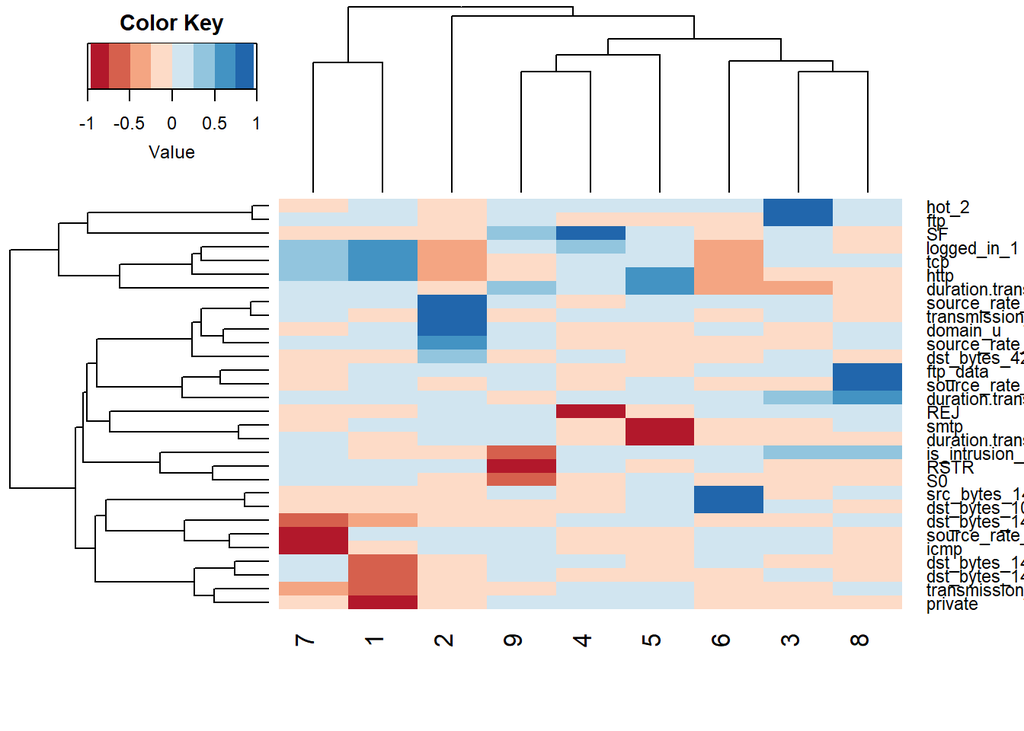

```r
fa_loadings <- state_vec %>% horns_curve() %>% factor_analysis(state_vec, hc_points = .) %>% factor_analysis_results(fa_loadings_rotated)

row.names(fa_loadings) <- colnames(state_vec)

gplots::heatmap.2(fa_loadings, dendrogram = 'both', trace = 'none', density.info = 'none', breaks = seq(-1, 1, by = .25),
                  col = RColorBrewer::brewer.pal(8, 'RdBu'))
```

### Estimating outliers in the data

*We can use the Mahalanobis distances in a heatmap visualization to identify outlier values across our security log attributes and time blocks. The larger and brighter the dot the more significant the outlier is and deserves attention.*

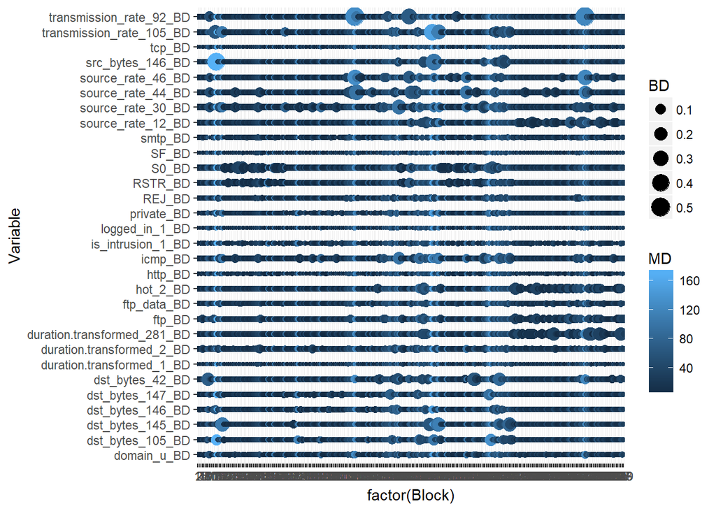

```r
#heatmap mahalonobis distance
state_vec %>%
  mahalanobis_distance("both", normalize = TRUE) %>%
  as_tibble %>%
  dplyr::mutate(Block = 1:n()) %>%
  gather(Variable, BD, -c(MD, Block)) %>%
  ggplot(aes(factor(Block), Variable, color = MD, size = BD)) +
  geom_point()
```

*We use the rotated factor score plots to see the time blocks that appear to be outliers and deserve closer attention as they are anomalies.*

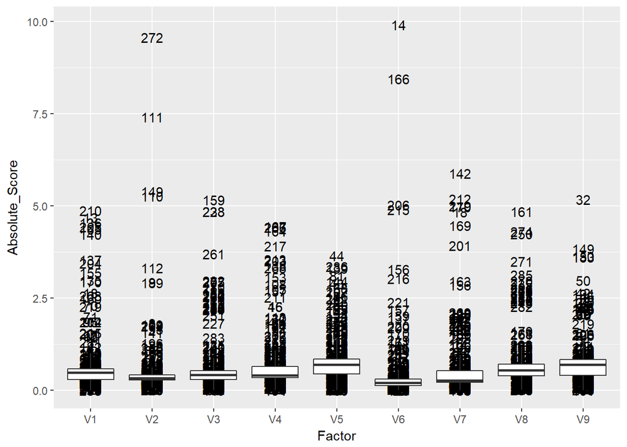

```r
state_vec %>%
  horns_curve() %>%
  factor_analysis(state_vec, hc_points = .) %>%
  factor_analysis_results(fa_scores_rotated) %>%
  as_tibble() %>%
  dplyr::mutate(Block = 1:n()) %>%
  gather(Factor, Score, -Block) %>%
  dplyr::mutate(Absolute_Score = abs(Score)) %>%
  ggplot(aes(Factor, Absolute_Score, label = Block)) +
  geom_text() +
  geom_boxplot(outlier.shape = NA)
```

*This allows us to look across the factors and identify outlier blocks that may require further intra-block analysis.* *From the plot, we can clearly see that values 272, 14, 111, 166, 142, 32 are anomalies in the data.*

## *Detection Power of the system*

**Evaluating the detection power of our system**

*The Kaisers index value for the anomaly detection system gives us a value of 0.8250 is a good performance metric as mentioned earlier. Combining this Anomaly Detection system with the classification of randomForest from the first task, we can get high levels of network intrusion detections.*

*The randomForest gives us high sensitivity while reducing the specificity, resulting in not failing to flag network activities that could be potential network intrusions. The value of the system in this domain is to study anomalous network behaviour rather than ignore it as a normal or non-intrusion attack.*

*The cost of not flagging a potential attack or anomaly is much higher than flagging a benign session as an intrusion and analysing it in detail. The goal in this project is to increase the sensitivity to lower costs of network intrusions in the banking system.*

```r
network.real <- network.traffic

network.limit <- filter(network.real, network.real$duration == 2)

network.limit <- dplyr::select(network.limit, -c(hot, num_compromised, root_shell, su_attempted, num_root, num_shells, num_access_files, is_guest_login))

str(network.limit)
```

```
## 'data.frame':    24 obs. of  9 variables:
##  $ duration          : int  2 2 2 2 2 2 2 2 2 2 ...
##  $ protocol_type     : Factor w/ 3 levels "icmp","tcp","udp": 3 2 2 2 2 3 2 2 2 2 ...
##  $ service           : Factor w/ 16 levels "auth","domain_u",..: 12 13 13 13 15 12 13 13 13 13 ...
##  $ flag              : Factor w/ 6 levels "REJ","RSTO","RSTR",..: 6 6 6 6 6 6 6 6 6 6 ...
##  $ src_bytes         : int  105 635 1398 2150 0 105 878 787 2769 3092 ...
##  $ dst_bytes         : int  146 330 367 372 4 146 333 330 337 333 ...
##  $ logged_in         : int  0 1 1 1 0 0 1 1 1 1 ...
##  $ num_file_creations: int  0 0 0 0 0 0 1 1 0 0 ...
##  $ is_intrusion      : Factor w/ 2 levels "0","1": 1 1 1 1 1 2 1 1 1 1 ...
```

```r
network.limit <- network.limit %>% mutate(source_rate = src_bytes/duration) %>% mutate(dest_rate = dst_bytes/duration)

levels(network.limit$service)
```

```
##  [1] "auth"     "domain_u" "eco_i"    "ecr_i"    "finger"   "ftp"
##  [7] "ftp_data" "http"     "ntp_u"    "other"    "pop_3"    "private"
## [13] "smtp"     "telnet"   "time"     "urp_i"
```

## *References*

1. Gareth James, Daniela Witten, Trevor Hastie and Robert Tibshirani An Introduction to Statistical Learning: with Applications in R http://www-bcf.usc.edu/~gareth/ISL/
2. 94-842 R Programming class http://www.andrew.cmu.edu/user/achoulde/94842/index.html
3. 95-791 Data Mining class material and homeworks http://www.andrew.cmu.edu/user/achoulde/95791/
4. Anomaly Detection Package https://cran.r-project.org/web/packages/anomalyDetection/vignettes/Introduction.html
5. Quick-R Cluster Analysis https://www.statmethods.net/advstats/cluster.html
6. Hierarchical cluster analysis on famous data sets - enhanced with the dendextend package: Tal Galili https://cran.r-project.org/web/packages/dendextend/vignettes/Cluster_Analysis.html
7. Dataset and its description http://kdd.ics.uci.edu/databases/kddcup99/task.html
8. Gower distance http://www.sthda.com/english/articles/26-clustering-basics/86-clustering-distance-measures-essentials/